# WineWords

### Imports

```python
import pandas as pd
import math
import re
from sklearn.feature_extraction import stop_words
from sklearn.feature_extraction.text import TfidfVectorizer
from sklearn.feature_extraction.text import CountVectorizer
from nltk.tokenize import word_tokenize
nltk.download('punkt')
from collections import Counter
import matplotlib.pyplot as plt
import numpy as np
from wordcloud import WordCloud
%matplotlib inline
```

## Gather the data

```python
df = pd.read_csv("winemag-data-130k-v2.csv")
```

#### Read in additional stop wine-related stop words

I created this list by listing the most frequent words in the reviews and then removing from the list and words that are usefully descriptive. What remained was this list of common words used in wine descriptions that don't describe the wine.

```python
with open('wine_stop.txt') as f:
    wine_stop = f.read().splitlines()
```

```python
wine_stop
```

```
['wine',
 'flavors',
 'fruit',
 'aromas',
 'palate',
 'finish',
 'drink',
 'red',
 'notes',
 'nose',
 'blend',
 'white',
 'offers',
 'texture',
 'bodied',
 'shows',
 'cabernet',
 'good',
 'touch',
 'character',
 'like',
 'sauvignon',
 'years',
 'fine',
 'pinot',
 'just',
 'style',
 'mouth',
 'long',
 'note',
 'vineyard',
 'flavor',
 'merlot',
 'hint',
 'bit',
 'age',
 'balance',
 'opens',
 'syrah',
 'alongside',
```

[output cut: 501 more lines]

```
 'filled',
 '2030',
 'early',
 'terms',
 'defined',
 'pleasure',
 'parts',
 'including',
 'complete',
 'streaks',
 'definitely',
 'gold',
 'edgy',
 'shape',
 'rock']
```

## Access the data

```python
df.columns.values[0] = "index"
df.head()
```

|  | index | country | description | designation | points | price | province | region_1 | region_2 | taster_name | taster_twitter_handle | title | variety | winery |
| --- | --- | --- | --- | --- | --- | --- | --- | --- | --- | --- | --- | --- | --- | --- |
| 0 | 0 | Italy | Aromas include tropical fruit, broom, brimston... | Vulkà Bianco | 87 | NaN | Sicily & Sardinia | Etna | NaN | Kerin O’Keefe | @kerinokeefe | Nicosia 2013 Vulkà Bianco (Etna) | White Blend | Nicosia |
| 1 | 1 | Portugal | This is ripe and fruity, a wine that is smooth... | Avidagos | 87 | 15.0 | Douro | NaN | NaN | Roger Voss | @vossroger | Quinta dos Avidagos 2011 Avidagos Red (Douro) | Portuguese Red | Quinta dos Avidagos |
| 2 | 2 | US | Tart and snappy, the flavors of lime flesh and... | NaN | 87 | 14.0 | Oregon | Willamette Valley | Willamette Valley | Paul Gregutt | @paulgwine | Rainstorm 2013 Pinot Gris (Willamette Valley) | Pinot Gris | Rainstorm |
| 3 | 3 | US | Pineapple rind, lemon pith and orange blossom ... | Reserve Late Harvest | 87 | 13.0 | Michigan | Lake Michigan Shore | NaN | Alexander Peartree | NaN | St. Julian 2013 Reserve Late Harvest Riesling ... | Riesling | St. Julian |
| 4 | 4 | US | Much like the regular bottling from 2012, this... | Vintner's Reserve Wild Child Block | 87 | 65.0 | Oregon | Willamette Valley | Willamette Valley | Paul Gregutt | @paulgwine | Sweet Cheeks 2012 Vintner's Reserve Wild Child... | Pinot Noir | Sweet Cheeks |

```python
df.description[0]
```

```
"Aromas include tropical fruit, broom, brimstone and dried herb. The palate isn't overly expressive, offering unripened apple, citrus and dried sage alongside brisk acidity."
```

```python
df.describe()
```

|  | index | points | price |
| --- | --- | --- | --- |
| count | 129971.000000 | 129971.000000 | 120975.000000 |
| mean | 64985.000000 | 88.447138 | 35.363389 |
| std | 37519.540256 | 3.039730 | 41.022218 |
| min | 0.000000 | 80.000000 | 4.000000 |
| 25% | 32492.500000 | 86.000000 | 17.000000 |
| 50% | 64985.000000 | 88.000000 | 25.000000 |
| 75% | 97477.500000 | 91.000000 | 42.000000 |
| max | 129970.000000 | 100.000000 | 3300.000000 |

# Examine the dataset for NaNs. Clean the data

```python
df.isnull().sum()
```

```
index                        0
country                     63
description                  0
designation              37465
points                       0
price                     8996
province                    63
region_1                 21247
region_2                 79460
taster_name              26244
taster_twitter_handle    31213
title                        0
variety                      1
winery                       0
dtype: int64
```

#### Columns with no or little missing data

- description
- points
- title
- variety
- winery
- country
- province

```python
df[df.variety.isnull()]
```

|  | index | country | description | designation | points | price | province | region_1 | region_2 | taster_name | taster_twitter_handle | title | variety | winery |
| --- | --- | --- | --- | --- | --- | --- | --- | --- | --- | --- | --- | --- | --- | --- |
| 86909 | 86909 | Chile | A chalky, dusty mouthfeel nicely balances this... | NaN | 88 | 17.0 | Maipo Valley | NaN | NaN | NaN | NaN | Carmen 1999 (Maipo Valley) | NaN | Carmen |

The single row missing the variety (and other features) won't be missed, so I'm deleting it.

```python
df = df.drop(index=86909)
```

```python
df.country.isnull().sum()/df.shape[0]
```

```
0.0004847272447487882
```

```python
df[df.country.isnull() | df.province.isnull()]
```

[output not shown]

63 rows × 14 columns

Also deleting the 63 rows missing country and province values. These represent less than .1% of the data.

```python
indexes_to_drop = df[df.country.isnull()].index
```

```python
df = df.drop(index=indexes_to_drop)
```

```python
df.isnull().sum()
```

```
index                        0
country                      0
description                  0
designation              37453
points                       0
price                     8992
province                     0
region_1                 21183
region_2                 79396
taster_name              26243
taster_twitter_handle    31212
title                        0
variety                      0
winery                       0
dtype: int64
```

#### Columns with significant missing data

- designation
- price
- region_1
- region_2
- taster_name
- taster_twitter_handle

For this analysis, I may not neet the taster name or twitter handle, but I'll leave the columns in for now. There's really no way to impute this info.

#### Explore region_1, region_2 features

```python
pd.unique(df.region_2)
```

```
array([nan, 'Willamette Valley', 'Napa', 'Sonoma', 'Central Coast',
       'Oregon Other', 'Central Valley', 'North Coast', 'Columbia Valley',
       'California Other', 'Finger Lakes', 'Sierra Foothills',
       'New York Other', 'Long Island', 'Napa-Sonoma', 'Southern Oregon',
       'Washington Other', 'South Coast'], dtype=object)
```

```python
df[df.region_1.notnull() &  df.region_2.isnull()]
```

|  | index | country | description | designation | points | price | province | region_1 | region_2 | taster_name | taster_twitter_handle | title | variety | winery |
| --- | --- | --- | --- | --- | --- | --- | --- | --- | --- | --- | --- | --- | --- | --- |
| 0 | 0 | Italy | Aromas include tropical fruit, broom, brimston... | Vulkà Bianco | 87 | NaN | Sicily & Sardinia | Etna | NaN | Kerin O’Keefe | @kerinokeefe | Nicosia 2013 Vulkà Bianco (Etna) | White Blend | Nicosia |
| 3 | 3 | US | Pineapple rind, lemon pith and orange blossom ... | Reserve Late Harvest | 87 | 13.0 | Michigan | Lake Michigan Shore | NaN | Alexander Peartree | NaN | St. Julian 2013 Reserve Late Harvest Riesling ... | Riesling | St. Julian |
| 5 | 5 | Spain | Blackberry and raspberry aromas show a typical... | Ars In Vitro | 87 | 15.0 | Northern Spain | Navarra | NaN | Michael Schachner | @wineschach | Tandem 2011 Ars In Vitro Tempranillo-Merlot (N... | Tempranillo-Merlot | Tandem |
| 6 | 6 | Italy | Here's a bright, informal red that opens with ... | Belsito | 87 | 16.0 | Sicily & Sardinia | Vittoria | NaN | Kerin O’Keefe | @kerinokeefe | Terre di Giurfo 2013 Belsito Frappato (Vittoria) | Frappato | Terre di Giurfo |
| 7 | 7 | France | This dry and restrained wine offers spice in p... | NaN | 87 | 24.0 | Alsace | Alsace | NaN | Roger Voss | @vossroger | Trimbach 2012 Gewurztraminer (Alsace) | Gewürztraminer | Trimbach |
| 9 | 9 | France | This has great depth of flavor with its fresh ... | Les Natures | 87 | 27.0 | Alsace | Alsace | NaN | Roger Voss | @vossroger | Jean-Baptiste Adam 2012 Les Natures Pinot Gris... | Pinot Gris | Jean-Baptiste Adam |
| 11 | 11 | France | This is a dry wine, very spicy, with a tight, ... | NaN | 87 | 30.0 | Alsace | Alsace | NaN | Roger Voss | @vossroger | Leon Beyer 2012 Gewurztraminer (Alsace) | Gewürztraminer | Leon Beyer |
| 13 | 13 | Italy | This is dominated by oak and oak-driven aromas... | Rosso | 87 | NaN | Sicily & Sardinia | Etna | NaN | Kerin O’Keefe | @kerinokeefe | Masseria Setteporte 2012 Rosso (Etna) | Nerello Mascalese | Masseria Setteporte |
| 16 | 16 | Argentina | Baked plum, molasses, balsamic vinegar and che... | Felix | 87 | 30.0 | Other | Cafayate | NaN | Michael Schachner | @wineschach | Felix Lavaque 2010 Felix Malbec (Cafayate) | Malbec | Felix Lavaque |
| 17 | 17 | Argentina | Raw black-cherry aromas are direct and simple ... | Winemaker Selection | 87 | 13.0 | Mendoza Province | Mendoza | NaN | Michael Schachner | @wineschach | Gaucho Andino 2011 Winemaker Selection Malbec ... | Malbec | Gaucho Andino |
| 18 | 18 | Spain | Desiccated blackberry, leather, charred wood a... | Vendimia Seleccionada Finca Valdelayegua Singl... | 87 | 28.0 | Northern Spain | Ribera del Duero | NaN | Michael Schachner | @wineschach | Pradorey 2010 Vendimia Seleccionada Finca Vald... | Tempranillo Blend | Pradorey |
| 19 | 19 | US | Red fruit aromas pervade on the nose, with cig... | NaN | 87 | 32.0 | Virginia | Virginia | NaN | Alexander Peartree | NaN | Quiévremont 2012 Meritage (Virginia) | Meritage | Quiévremont |
| 20 | 20 | US | Ripe aromas of dark berries mingle with ample ... | Vin de Maison | 87 | 23.0 | Virginia | Virginia | NaN | Alexander Peartree | NaN | Quiévremont 2012 Vin de Maison Red (Virginia) | Red Blend | Quiévremont |
| 22 | 22 | Italy | Delicate aromas recall white flower and citrus... | Ficiligno | 87 | 19.0 | Sicily & Sardinia | Sicilia | NaN | Kerin O’Keefe | @kerinokeefe | Baglio di Pianetto 2007 Ficiligno White (Sicilia) | White Blend | Baglio di Pianetto |
| 24 | 24 | Italy | Aromas of prune, blackcurrant, toast and oak c... | Aynat | 87 | 35.0 | Sicily & Sardinia | Sicilia | NaN | Kerin O’Keefe | @kerinokeefe | Canicattì 2009 Aynat Nero d'Avola (Sicilia) | Nero d'Avola | Canicattì |
| 26 | 26 | Italy | Pretty aromas of yellow flower and stone fruit... | Dalila | 87 | 13.0 | Sicily & Sardinia | Terre Siciliane | NaN | Kerin O’Keefe | @kerinokeefe | Stemmari 2013 Dalila White (Terre Siciliane) | White Blend | Stemmari |
| 27 | 27 | Italy | Aromas recall ripe dark berry, toast and a whi... | NaN | 87 | 10.0 | Sicily & Sardinia | Terre Siciliane | NaN | Kerin O’Keefe | @kerinokeefe | Stemmari 2013 Nero d'Avola (Terre Siciliane) | Nero d'Avola | Stemmari |
| 28 | 28 | Italy | Aromas suggest mature berry, scorched earth, a... | Mascaria Barricato | 87 | 17.0 | Sicily & Sardinia | Cerasuolo di Vittoria | NaN | Kerin O’Keefe | @kerinokeefe | Terre di Giurfo 2011 Mascaria Barricato (Cera... | Red Blend | Terre di Giurfo |
| 30 | 30 | France | Red cherry fruit comes laced with light tannin... | Nouveau | 86 | NaN | Beaujolais | Beaujolais-Villages | NaN | Roger Voss | @vossroger | Domaine de la Madone 2012 Nouveau (Beaujolais... | Gamay | Domaine de la Madone |
| 31 | 31 | Italy | Merlot and Nero d'Avola form the base for this... | Calanìca Nero d'Avola-Merlot | 86 | NaN | Sicily & Sardinia | Sicilia | NaN | NaN | NaN | Duca di Salaparuta 2010 Calanìca Nero d'Avola-... | Red Blend | Duca di Salaparuta |
| 32 | 32 | Italy | Part of the extended Calanìca series, this Gri... | Calanìca Grillo-Viognier | 86 | NaN | Sicily & Sardinia | Sicilia | NaN | NaN | NaN | Duca di Salaparuta 2011 Calanìca Grillo-Viogni... | White Blend | Duca di Salaparuta |
| 37 | 37 | Italy | This concentrated Cabernet offers aromas of cu... | Missoni | 86 | 21.0 | Sicily & Sardinia | Sicilia | NaN | NaN | NaN | Feudi del Pisciotto 2010 Missoni Cabernet Sauv... | Cabernet Sauvignon | Feudi del Pisciotto |
| 38 | 38 | Italy | Inky in color, this wine has plump aromas of r... | I Tratturi | 86 | 11.0 | Southern Italy | Puglia | NaN | NaN | NaN | Feudi di San Marzano 2011 I Tratturi Primitivo... | Primitivo | Feudi di San Marzano |
| 39 | 39 | Italy | Part of the natural wine movement, this wine i... | Purato Made With Organic Grapes | 86 | 12.0 | Sicily & Sardinia | Sicilia | NaN | NaN | NaN | Feudo di Santa Tresa 2011 Purato Made With Org... | Nero d'Avola | Feudo di Santa Tresa |
| 40 | 40 | Italy | Catarratto is one of Sicily's most widely farm... | NaN | 86 | 17.0 | Sicily & Sardinia | Sicilia | NaN | NaN | NaN | Feudo Montoni 2011 Catarratto (Sicilia) | Catarratto | Feudo Montoni |
| 42 | 42 | France | This is a festive wine, with soft, ripe fruit ... | Nouveau | 86 | 9.0 | Beaujolais | Beaujolais | NaN | Roger Voss | @vossroger | Henry Fessy 2012 Nouveau (Beaujolais) | Gamay | Henry Fessy |
| 45 | 45 | US | Right out of the starting blocks this is an oa... | #SocialSecret | 86 | 40.0 | Virginia | Virginia | NaN | NaN | NaN | Tarara 2010 #SocialSecret Red (Virginia) | Red Blend | Tarara |
| 46 | 46 | Italy | Spicy, fresh and clean, this would pair with f... | Sallier de la Tour | 86 | 13.0 | Sicily & Sardinia | Sicilia | NaN | NaN | NaN | Tasca d'Almerita 2011 Sallier de la Tour Inzol... | Inzolia | Tasca d'Almerita |
| 47 | 47 | US | This is a sweet wine with flavors of white sug... | NaN | 86 | 13.0 | California | Lake County | NaN | NaN | NaN | The White Knight 2011 Riesling (Lake County) | Riesling | The White Knight |
| 48 | 48 | US | This bottling resembles the New Zealand paradi... | NaN | 86 | 16.0 | Virginia | Monticello | NaN | NaN | NaN | Trump 2011 Sauvignon Blanc (Monticello) | Sauvignon Blanc | Trump |
| ... | ... | ... | ... | ... | ... | ... | ... | ... | ... | ... | ... | ... | ... | ... |
| 129893 | 129893 | Italy | Aromas of passion fruit, hay and a vegetal not... | Corte Menini | 91 | NaN | Veneto | Soave Classico | NaN | Kerin O’Keefe | @kerinokeefe | Le Mandolare 2015 Corte Menini (Soave Classico) | Garganega | Le Mandolare |
| 129894 | 129894 | France | Despite its proximity to Bordeaux, the Marmand... | NaN | 91 | 15.0 | Southwest France | Côtes du Marmandais | NaN | Roger Voss | @vossroger | Lionel Osmin & Cie 2014 Abouriou (Côtes du Mar... | Abouriou | Lionel Osmin & Cie |
| 129902 | 129902 | Spain | Dry apple and lemon aromas are clean and one s... | Finca Las Marcas Fermentado en Barrica | 91 | 40.0 | Northern Spain | Rueda | NaN | Michael Schachner | @wineschach | Carlos Moro 2015 Finca Las Marcas Fermentado e... | Verdejo | Carlos Moro |
| 129903 | 129903 | France | A fine value for a northern Rhône of this qual... | Grand Classique | 91 | 27.0 | Rhône Valley | Saint-Péray | NaN | Joe Czerwinski | @JoeCz | Cave de Tain 2015 Grand Classique Marsanne (Sa... | Marsanne | Cave de Tain |
| 129905 | 129905 | France | This full-bodied, lush white is mainly Grenach... | NaN | 91 | 44.0 | Rhône Valley | Châteauneuf-du-Pape | NaN | Joe Czerwinski | @JoeCz | Château Maucoil 2014 White (Châteauneuf-du-Pape) | Rhône-style White Blend | Château Maucoil |
| 129917 | 129917 | Argentina | This dark, meaty Malbec has some Agrelo fruit ... | Piedra Negra | 91 | 40.0 | Mendoza Province | Mendoza | NaN | Michael Schachner | @wineschach | J. & F. Lurton 2004 Piedra Negra Malbec (Mendoza) | Malbec | J. & F. Lurton |
| 129921 | 129921 | Argentina | There is a select group of under-$20 Malbecs f... | La Madras Vineyard | 91 | 18.0 | Mendoza Province | Mendoza | NaN | Michael Schachner | @wineschach | Ricardo Santos 2006 La Madras Vineyard Malbec ... | Malbec | Ricardo Santos |
| 129925 | 129925 | Argentina | A lively, well-made blend of Tempranillo, Malb... | B Crux | 91 | 24.0 | Mendoza Province | Uco Valley | NaN | Michael Schachner | @wineschach | O. Fournier 2005 B Crux Red (Uco Valley) | Red Blend | O. Fournier |
| 129928 | 129928 | Spain | This represents Torres' highest effort in Prio... | Salmos Perpetual | 91 | 52.0 | Catalonia | Priorat | NaN | Michael Schachner | @wineschach | Torres 2005 Salmos Perpetual Red (Priorat) | Red Blend | Torres |
| 129929 | 129929 | Italy | This luminous sparkler has a sweet, fruit-forw... | NaN | 91 | 38.0 | Veneto | Prosecco Superiore di Cartizze | NaN | NaN | NaN | Col Vetoraz Spumanti NV Prosecco Superiore di... | Prosecco | Col Vetoraz Spumanti |
| 129930 | 129930 | Spain | Arguably on the heavy and rich side, but if yo... | Crianza | 91 | 26.0 | Northern Spain | Ribera del Duero | NaN | Michael Schachner | @wineschach | Costaval 2005 Crianza (Ribera del Duero) | Tempranillo Blend | Costaval |
| 129931 | 129931 | France | A powerful, chunky wine, packed with solid tan... | NaN | 91 | 107.0 | Burgundy | Grands-Echezeaux | NaN | Roger Voss | @vossroger | Henri de Villamont 2005 Grands-Echezeaux | Pinot Noir | Henri de Villamont |
| 129932 | 129932 | Argentina | Andeluna's top wines tend to be ripe and plump... | Pasionado | 91 | 55.0 | Mendoza Province | Uco Valley | NaN | Michael Schachner | @wineschach | Andeluna 2004 Pasionado Red (Uco Valley) | Red Blend | Andeluna |
| 129936 | 129936 | France | A blend from several premier cru vineyards in ... | Premier Cru | 91 | 66.0 | Burgundy | Pommard | NaN | Roger Voss | @vossroger | Bouchard Père & Fils 2005 Premier Cru (Pommard) | Pinot Noir | Bouchard Père & Fils |
| 129938 | 129938 | Argentina | Compared to the regular 2006 Malbec from Chaka... | Reserve | 91 | 25.0 | Mendoza Province | Luján de Cuyo | NaN | Michael Schachner | @wineschach | Chakana 2006 Reserve Malbec (Luján de Cuyo) | Malbec | Chakana |
| 129940 | 129940 | US | This is the winery's bells and whistles Chardo... | Watson Vineyard | 91 | 36.0 | California | Mendocino | NaN | NaN | NaN | Standish 2006 Watson Vineyard Chardonnay (Mend... | Chardonnay | Standish |
| 129941 | 129941 | US | A Chardonnay with an unusual companion, 8% Sém... | NaN | 90 | 20.0 | California | Mendocino County | NaN | Virginie Boone | @vboone | Apriori 2013 Chardonnay (Mendocino County) | Chardonnay | Apriori |
| 129943 | 129943 | Italy | A blend of Nero d'Avola and Syrah, this convey... | Adènzia | 90 | 29.0 | Sicily & Sardinia | Sicilia | NaN | Kerin O’Keefe | @kerinokeefe | Baglio del Cristo di Campobello 2012 Adènzia R... | Red Blend | Baglio del Cristo di Campobello |
| 129947 | 129947 | Italy | A blend of 65% Cabernet Sauvignon, 30% Merlot ... | Symposio | 90 | 20.0 | Sicily & Sardinia | Terre Siciliane | NaN | Kerin O’Keefe | @kerinokeefe | Feudo Principi di Butera 2012 Symposio Red (Te... | Red Blend | Feudo Principi di Butera |
| 129948 | 129948 | Argentina | Raspberry and cassis aromas are fresh and upri... | Pedernal | 90 | 43.0 | Other | San Juan | NaN | Michael Schachner | @wineschach | Finca Las Moras 2010 Pedernal Malbec (San Juan) | Malbec | Finca Las Moras |
| 129951 | 129951 | France | Hugely spicy this rich wine is described as sw... | Holder | 90 | 30.0 | Alsace | Alsace | NaN | Roger Voss | @vossroger | Henri Schoenheitz 2012 Holder Gewurztraminer (... | Gewürztraminer | Henri Schoenheitz |
| 129957 | 129957 | Spain | Lightly baked berry aromas vie for attention w... | Crianza | 90 | 17.0 | Northern Spain | Rioja | NaN | Michael Schachner | @wineschach | Viñedos Real Rubio 2010 Crianza (Rioja) | Tempranillo Blend | Viñedos Real Rubio |
| 129959 | 129959 | France | The granite soil of the Brand Grand Cru vineya... | Brand Grand Cru | 90 | 57.0 | Alsace | Alsace | NaN | Roger Voss | @vossroger | Cave de Turckheim 2010 Brand Grand Cru Pinot G... | Pinot Gris | Cave de Turckheim |
| 129961 | 129961 | Italy | Intense aromas of wild cherry, baking spice, t... | NaN | 90 | 30.0 | Sicily & Sardinia | Sicilia | NaN | Kerin O’Keefe | @kerinokeefe | COS 2013 Frappato (Sicilia) | Frappato | COS |
| 129962 | 129962 | Italy | Blackberry, cassis, grilled herb and toasted a... | Sàgana Tenuta San Giacomo | 90 | 40.0 | Sicily & Sardinia | Sicilia | NaN | Kerin O’Keefe | @kerinokeefe | Cusumano 2012 Sàgana Tenuta San Giacomo Nero d... | Nero d'Avola | Cusumano |
| 129964 | 129964 | France | Initially quite muted, this wine slowly develo... | Domaine Saint-Rémy Herrenweg | 90 | NaN | Alsace | Alsace | NaN | Roger Voss | @vossroger | Domaine Ehrhart 2013 Domaine Saint-Rémy Herren... | Gewürztraminer | Domaine Ehrhart |
| 129965 | 129965 | France | While it's rich, this beautiful dry wine also ... | Seppi Landmann Vallée Noble | 90 | 28.0 | Alsace | Alsace | NaN | Roger Voss | @vossroger | Domaine Rieflé-Landmann 2013 Seppi Landmann Va... | Pinot Gris | Domaine Rieflé-Landmann |
| 129968 | 129968 | France | Well-drained gravel soil gives this wine its c... | Kritt | 90 | 30.0 | Alsace | Alsace | NaN | Roger Voss | @vossroger | Domaine Gresser 2013 Kritt Gewurztraminer (Als... | Gewürztraminer | Domaine Gresser |
| 129969 | 129969 | France | A dry style of Pinot Gris, this is crisp with ... | NaN | 90 | 32.0 | Alsace | Alsace | NaN | Roger Voss | @vossroger | Domaine Marcel Deiss 2012 Pinot Gris (Alsace) | Pinot Gris | Domaine Marcel Deiss |
| 129970 | 129970 | France | Big, rich and off-dry, this is powered by inte... | Lieu-dit Harth Cuvée Caroline | 90 | 21.0 | Alsace | Alsace | NaN | Roger Voss | @vossroger | Domaine Schoffit 2012 Lieu-dit Harth Cuvée Car... | Gewürztraminer | Domaine Schoffit |

58213 rows × 14 columns

```python
df[df.region_2.notnull() & (df.region_1 != df.region_2)]
```

|  | index | country | description | designation | points | price | province | region_1 | region_2 | taster_name | taster_twitter_handle | title | variety | winery |
| --- | --- | --- | --- | --- | --- | --- | --- | --- | --- | --- | --- | --- | --- | --- |
| 10 | 10 | US | Soft, supple plum envelopes an oaky structure ... | Mountain Cuvée | 87 | 19.0 | California | Napa Valley | Napa | Virginie Boone | @vboone | Kirkland Signature 2011 Mountain Cuvée Caberne... | Cabernet Sauvignon | Kirkland Signature |
| 12 | 12 | US | Slightly reduced, this wine offers a chalky, t... | NaN | 87 | 34.0 | California | Alexander Valley | Sonoma | Virginie Boone | @vboone | Louis M. Martini 2012 Cabernet Sauvignon (Alex... | Cabernet Sauvignon | Louis M. Martini |
| 21 | 21 | US | A sleek mix of tart berry, stem and herb, alon... | NaN | 87 | 20.0 | Oregon | Oregon | Oregon Other | Paul Gregutt | @paulgwine | Acrobat 2013 Pinot Noir (Oregon) | Pinot Noir | Acrobat |
| 23 | 23 | US | This wine from the Geneseo district offers aro... | Signature Selection | 87 | 22.0 | California | Paso Robles | Central Coast | Matt Kettmann | @mattkettmann | Bianchi 2011 Signature Selection Merlot (Paso ... | Merlot | Bianchi |
| 25 | 25 | US | Oak and earth intermingle around robust aromas... | King Ridge Vineyard | 87 | 69.0 | California | Sonoma Coast | Sonoma | Virginie Boone | @vboone | Castello di Amorosa 2011 King Ridge Vineyard P... | Pinot Noir | Castello di Amorosa |
| 29 | 29 | US | Clarksburg is becoming a haven for Chenin Blan... | NaN | 86 | 16.0 | California | Clarksburg | Central Valley | Virginie Boone | @vboone | Clarksburg Wine Company 2010 Chenin Blanc (Cla... | Chenin Blanc | Clarksburg Wine Company |
| 33 | 33 | US | Rustic and dry, this has flavors of berries, c... | Puma Springs Vineyard | 86 | 50.0 | California | Dry Creek Valley | Sonoma | NaN | NaN | Envolve 2010 Puma Springs Vineyard Red (Dry Cr... | Red Blend | Envolve |
| 34 | 34 | US | This shows a tart, green gooseberry flavor tha... | NaN | 86 | 20.0 | California | Sonoma Valley | Sonoma | NaN | NaN | Envolve 2011 Sauvignon Blanc (Sonoma Valley) | Sauvignon Blanc | Envolve |
| 35 | 35 | US | As with many of the Erath 2010 vineyard design... | Hyland | 86 | 50.0 | Oregon | McMinnville | Willamette Valley | Paul Gregutt | @paulgwine | Erath 2010 Hyland Pinot Noir (McMinnville) | Pinot Noir | Erath |
| 43 | 43 | US | The clean, brisk mouthfeel gives this slightly... | NaN | 86 | 14.0 | California | Paso Robles | Central Coast | NaN | NaN | Robert Hall 2011 Sauvignon Blanc (Paso Robles) | Sauvignon Blanc | Robert Hall |
| 55 | 55 | US | This shows jelly-like flavors of orange and pe... | Estate Bottled | 85 | 30.0 | California | Napa Valley | Napa | NaN | NaN | RustRidge 2010 Estate Bottled Chardonnay (Napa... | Chardonnay | RustRidge |
| 59 | 59 | US | Aromas of cranberry, barrel spice and herb are... | NaN | 86 | 55.0 | Washington | Columbia Valley (WA) | Columbia Valley | Sean P. Sullivan | @wawinereport | Mellisoni 2014 Malbec (Columbia Valley (WA)) | Malbec | Mellisoni |
| 60 | 60 | US | Syrupy and dense, this wine is jammy in plum a... | Estate | 86 | 100.0 | California | Napa Valley | Napa | Virginie Boone | @vboone | Okapi 2013 Estate Cabernet Sauvignon (Napa Val... | Cabernet Sauvignon | Okapi |
| 62 | 62 | US | The aromas are brooding, with notes of barrel ... | Alder Ridge Vineyard | 86 | 25.0 | Washington | Columbia Valley (WA) | Columbia Valley | Sean P. Sullivan | @wawinereport | Ram 2014 Alder Ridge Vineyard Cabernet Franc (... | Cabernet Franc | Ram |
| 64 | 64 | US | There are intriguing touches to the nose of th... | Golden Horn | 86 | 26.0 | California | Santa Ynez Valley | Central Coast | Matt Kettmann | @mattkettmann | Sevtap 2015 Golden Horn Sauvignon Blanc (Santa... | Sauvignon Blanc | Sevtap |
| 67 | 67 | US | A blend of Merlot and Cabernet Franc, this win... | Inspired | 86 | 46.0 | Washington | Columbia Valley (WA) | Columbia Valley | Sean P. Sullivan | @wawinereport | Basel Cellars 2013 Inspired Red (Columbia Vall... | Bordeaux-style Red Blend | Basel Cellars |
| 68 | 68 | US | Very deep in color and spicy-smoky in flavor, ... | NaN | 86 | 12.0 | California | California | California Other | Jim Gordon | @gordone_cellars | Cocobon 2014 Red (California) | Red Blend | Cocobon |
| 70 | 70 | US | Aromas of vanilla, char and toast lead to ligh... | NaN | 86 | 12.0 | Washington | Columbia Valley (WA) | Columbia Valley | Sean P. Sullivan | @wawinereport | Drumheller 2014 Chardonnay (Columbia Valley (WA)) | Chardonnay | Drumheller |
| 71 | 71 | US | Big oak defines this robustly dense and extrac... | Old Vine | 86 | 40.0 | California | Alexander Valley | Sonoma | Virginie Boone | @vboone | Eco Terreno 2013 Old Vine Cabernet Sauvignon (... | Cabernet Sauvignon | Eco Terreno |
| 73 | 73 | US | Juicy plum, raspberry and pencil lead lead the... | Bella Vetta Vineyard | 86 | 75.0 | California | Howell Mountain | Napa | Virginie Boone | @vboone | Hindsight 2013 Bella Vetta Vineyard Cabernet S... | Cabernet Sauvignon | Hindsight |
| 74 | 74 | US | This is the producer's first release of this w... | Estate Grown | 86 | 55.0 | California | Calistoga | Napa | Virginie Boone | @vboone | Hindsight 2012 Estate Grown Petite Sirah (Cali... | Petite Sirah | Hindsight |
| 75 | 75 | US | This is made from equal parts Cabernet Franc a... | The Cypher | 86 | 75.0 | California | Napa Valley | Napa | Virginie Boone | @vboone | Mulvane Wine Co. 2013 The Cypher Red (Napa Val... | Bordeaux-style Red Blend | Mulvane Wine Co. |
| 78 | 78 | US | Some rosés are made simply by bleeding the jui... | Rosé of | 86 | 25.0 | Oregon | Eola-Amity Hills | Willamette Valley | Paul Gregutt | @paulgwine | Z'IVO 2015 Rosé of Pinot Noir (Eola-Amity Hills) | Pinot Noir | Z'IVO |
| 84 | 84 | US | A healthy addition of 13% Petite Sirah provide... | Classic | 86 | 24.0 | California | Napa Valley | Napa | Virginie Boone | @vboone | Napa Cellars 2014 Classic Zinfandel (Napa Valley) | Zinfandel | Napa Cellars |
| 86 | 86 | US | Vibrant aromas of ripe pear, white flowers and... | NaN | 86 | 20.0 | Washington | Ancient Lakes | Columbia Valley | Sean P. Sullivan | @wawinereport | Palencia 2016 Albariño (Ancient Lakes) | Albariño | Palencia |
| 87 | 87 | US | Softened tannins surround a light-bodied, lean... | Blau Vineyards | 86 | 55.0 | California | Knights Valley | Sonoma | Virginie Boone | @vboone | Passaggio 2014 Blau Vineyards Merlot (Knights ... | Merlot | Passaggio |
| 90 | 90 | US | This blend of Sangiovese, Malbec, Cabernet Sau... | Siena | 88 | 23.0 | California | Sonoma County | Sonoma | Virginie Boone | @vboone | Ferrari-Carano 2014 Siena Red (Sonoma County) | Red Blend | Ferrari-Carano |
| 91 | 91 | US | This wine has a touch of perceptible sweetness... | NaN | 88 | 18.0 | California | Sonoma Coast | Sonoma | Virginie Boone | @vboone | Folie à Deux 2015 Pinot Gris (Sonoma Coast) | Pinot Gris | Folie à Deux |
| 92 | 92 | US | All red Bordeaux varieties are represented in ... | Magnificat | 88 | 55.0 | California | Napa Valley | Napa | Virginie Boone | @vboone | Franciscan 2013 Magnificat Meritage (Napa Valley) | Meritage | Franciscan |
| 94 | 94 | US | Barrel notes are prominent, with aromas of Cre... | Grand Klasse Reserve Lawrence Vineyards | 88 | 22.0 | Washington | Columbia Valley (WA) | Columbia Valley | Sean P. Sullivan | @wawinereport | Gård 2014 Grand Klasse Reserve Lawrence Vineya... | Viognier | Gård |
| ... | ... | ... | ... | ... | ... | ... | ... | ... | ... | ... | ... | ... | ... | ... |
| 129878 | 129878 | US | Light in color and nuanced in oak, this full-b... | Dutton Ranch | 90 | 46.0 | California | Russian River Valley | Sonoma | Virginie Boone | @vboone | MacRostie 2014 Dutton Ranch Chardonnay (Russia... | Chardonnay | MacRostie |
| 129879 | 129879 | US | This wine is a blend of 45% Grenache, 37% Syra... | Metis | 90 | 20.0 | Washington | Columbia Valley (WA) | Columbia Valley | Sean P. Sullivan | @wawinereport | Maison Bleue 2013 Metis Red (Columbia Valley (... | Red Blend | Maison Bleue |
| 129880 | 129880 | US | Apple blossom intrigues on the nose of this li... | NaN | 90 | 20.0 | California | Russian River Valley | Sonoma | Virginie Boone | @vboone | Martin Ray 2015 Chardonnay (Russian River Valley) | Chardonnay | Martin Ray |
| 129882 | 129882 | US | This wine is mostly Cabernet Sauvignon (78%), ... | Reserve | 90 | 60.0 | Washington | Columbia Valley (WA) | Columbia Valley | Sean P. Sullivan | @wawinereport | Matthews 2012 Reserve Red (Columbia Valley (WA)) | Bordeaux-style Red Blend | Matthews |
| 129885 | 129885 | US | Lemon-lime soda aromas meet with orange blosso... | NaN | 91 | 25.0 | California | Santa Ynez Valley | Central Coast | Matt Kettmann | @mattkettmann | Zaca Mesa 2013 Roussanne (Santa Ynez Valley) | Roussanne | Zaca Mesa |
| 129888 | 129888 | US | Round red cherry, deep plum and ripe cranberry... | NaN | 91 | 34.0 | California | Santa Lucia Highlands | Central Coast | Matt Kettmann | @mattkettmann | August West 2015 Pinot Noir (Santa Lucia Highl... | Pinot Noir | August West |
| 129891 | 129891 | US | Chocolate, mocha and coconut notes highlight t... | Estate Block 3 | 91 | 100.0 | California | Calistoga | Napa | Virginie Boone | @vboone | Jax 2013 Estate Block 3 Cabernet Sauvignon (Ca... | Cabernet Sauvignon | Jax |
| 129895 | 129895 | US | A blend of vineyards including the winery's Mi... | Limited Release | 91 | 30.0 | California | Green Valley | Sonoma | Virginie Boone | @vboone | Martin Ray 2015 Limited Release Chardonnay (Gr... | Chardonnay | Martin Ray |
| 129896 | 129896 | US | Smoothly seductive in texture and body, this m... | Stuhlmuller Vineyard Reserve | 91 | 36.0 | California | Alexander Valley | Sonoma | Virginie Boone | @vboone | Mazzocco 2014 Stuhlmuller Vineyard Reserve Cha... | Chardonnay | Mazzocco |
| 129897 | 129897 | US | This hearty, rich bottling needs time to breat... | NaN | 91 | 48.0 | California | Paso Robles | Central Coast | Matt Kettmann | @mattkettmann | MCV 2014 Petite Sirah (Paso Robles) | Petite Sirah | MCV |
| 129898 | 129898 | US | Plum and cherry fruit show on the nose of this... | Mare Nectaris Reserve | 91 | 52.0 | California | Paso Robles | Central Coast | Matt Kettmann | @mattkettmann | Midnight 2012 Mare Nectaris Reserve Red (Paso ... | Bordeaux-style Red Blend | Midnight |
| 129899 | 129899 | US | Aged entirely in stainless steel, this combine... | Proprietary | 91 | 30.0 | California | Napa Valley | Napa | Virginie Boone | @vboone | Paraduxx 2015 Proprietary White (Napa Valley) | White Blend | Paraduxx |
| 129904 | 129904 | US | A blend of Sauvignon Blanc, Sauvignon Gris and... | Estate Bottled | 91 | 33.0 | California | Chalk Hill | Sonoma | Virginie Boone | @vboone | Chalk Hill 2015 Estate Bottled Sauvignon Blanc... | Sauvignon Blanc | Chalk Hill |
| 129906 | 129906 | US | Pencil shaving and graphite notes lend a class... | NaN | 91 | 35.0 | California | Napa Valley | Napa | Virginie Boone | @vboone | Conn Creek 2013 Cabernet Sauvignon (Napa Valley) | Cabernet Sauvignon | Conn Creek |
| 129909 | 129909 | US | Hailing from an extreme coastal vineyard, this... | Derbyshire Vineyard | 91 | 20.0 | California | San Luis Obispo County | Central Coast | Matt Kettmann | @mattkettmann | Derby 2015 Derbyshire Vineyard Pinot Gris (San... | Pinot Gris | Derby |
| 129912 | 129912 | US | From the Ranch House block of the famous viney... | Durell Vineyard | 91 | 55.0 | California | Sonoma Coast | Sonoma | Virginie Boone | @vboone | Dunstan 2014 Durell Vineyard Pinot Noir (Sonom... | Pinot Noir | Dunstan |
| 129913 | 129913 | US | This is taut and dense, and requires time and ... | Artist Series #14 | 92 | 44.0 | Washington | Columbia Valley (WA) | Columbia Valley | Paul Gregutt | @paulgwine | Woodward Canyon 2005 Artist Series #14 Caberne... | Cabernet Sauvignon | Woodward Canyon |
| 129914 | 129914 | US | Fritz has made tremendous progress with Cab ov... | NaN | 91 | 35.0 | California | Dry Creek Valley | Sonoma | NaN | NaN | Fritz 2005 Cabernet Sauvignon (Dry Creek Valley) | Cabernet Sauvignon | Fritz |
| 129915 | 129915 | US | The third vintage of Mith is the best yet, com... | Mith Red Wine | 91 | 40.0 | Washington | Columbia Valley (WA) | Columbia Valley | Paul Gregutt | @paulgwine | Balboa 2005 Mith Red Wine Red (Columbia Valley... | Red Blend | Balboa |
| 129919 | 129919 | US | This ripe, rich, almost decadently thick wine ... | Reserve | 91 | 105.0 | Washington | Walla Walla Valley (WA) | Columbia Valley | Paul Gregutt | @paulgwine | Nicholas Cole Cellars 2004 Reserve Red (Walla ... | Red Blend | Nicholas Cole Cellars |
| 129920 | 129920 | US | Shows the clean, citrus acid juiciness and sil... | Fiddlestix Vineyard | 91 | 48.0 | California | Sta. Rita Hills | Central Coast | NaN | NaN | Pali 2006 Fiddlestix Vineyard Pinot Noir (Sta.... | Pinot Noir | Pali |
| 129926 | 129926 | US | This pure Syrah from Reininger's estate vineya... | Ash Hollow Vineyard | 91 | 41.0 | Washington | Walla Walla Valley (WA) | Columbia Valley | Paul Gregutt | @paulgwine | Reininger 2005 Ash Hollow Vineyard Syrah (Wall... | Syrah | Reininger |
| 129927 | 129927 | US | It's 100% Cabernet Franc, a delightful, bright... | NaN | 91 | 28.0 | Washington | Columbia Valley (WA) | Columbia Valley | Paul Gregutt | @paulgwine | Tamarack Cellars 2006 Cabernet Franc (Columbia... | Cabernet Franc | Tamarack Cellars |
| 129935 | 129935 | US | This has lovely raspberry and cranberry fruit,... | NaN | 91 | 38.0 | Washington | Columbia Valley-Walla Walla Valley | Columbia Valley | Paul Gregutt | @paulgwine | Va Piano 2006 Syrah (Columbia Valley-Walla Wal... | Syrah | Va Piano |
| 129942 | 129942 | US | This is classic in herbaceous aromas and flavo... | NaN | 90 | 35.0 | California | Sonoma County | Sonoma | Virginie Boone | @vboone | Arrowood 2010 Cabernet Sauvignon (Sonoma County) | Cabernet Sauvignon | Arrowood |
| 129945 | 129945 | US | Hailing from one of the more popular vineyards... | Jurassic Park Vineyard Old Vines | 90 | 20.0 | California | Santa Ynez Valley | Central Coast | Matt Kettmann | @mattkettmann | Birichino 2013 Jurassic Park Vineyard Old Vine... | Chenin Blanc | Birichino |
| 129949 | 129949 | US | There's no bones about the use of oak in this ... | Barrel Fermented | 90 | 35.0 | California | Napa Valley | Napa | Virginie Boone | @vboone | Flora Springs 2013 Barrel Fermented Chardonnay... | Chardonnay | Flora Springs |
| 129950 | 129950 | US | This opens with herbaceous dollops of thyme an... | Blocks 7 & 22 | 90 | 35.0 | California | Napa Valley | Napa | Virginie Boone | @vboone | Hendry 2012 Blocks 7 & 22 Zinfandel (Napa Valley) | Zinfandel | Hendry |
| 129952 | 129952 | US | This Zinfandel from the eastern section of Nap... | NaN | 90 | 22.0 | California | Chiles Valley | Napa | Virginie Boone | @vboone | Houdini 2011 Zinfandel (Chiles Valley) | Zinfandel | Houdini |
| 129967 | 129967 | US | Citation is given as much as a decade of bottl... | NaN | 90 | 75.0 | Oregon | Oregon | Oregon Other | Paul Gregutt | @paulgwine | Citation 2004 Pinot Noir (Oregon) | Pinot Noir | Citation |

45239 rows × 14 columns

region_1 is a more specific location while region_2 is more general. For example, region_2="Sonoma" is a general area while region_1="Chalk Hill" is a specific place in Sonoma. Several of the entries have the same value for region_1 and region_2, so where there is a region_1 value, but no region_2 value, I will copy the value from region_1 to region_2

```python
df.region_1 = df.province.where(df.region_1.isnull(), df.region_1)
df.region_2 = df.region_1.where(df.region_2.isnull(), df.region_2)
```

```python
df[df.region_1 != df.region_2]
```

|  | index | country | description | designation | points | price | province | region_1 | region_2 | taster_name | taster_twitter_handle | title | variety | winery |
| --- | --- | --- | --- | --- | --- | --- | --- | --- | --- | --- | --- | --- | --- | --- |
| 10 | 10 | US | Soft, supple plum envelopes an oaky structure ... | Mountain Cuvée | 87 | 19.0 | California | Napa Valley | Napa | Virginie Boone | @vboone | Kirkland Signature 2011 Mountain Cuvée Caberne... | Cabernet Sauvignon | Kirkland Signature |
| 12 | 12 | US | Slightly reduced, this wine offers a chalky, t... | NaN | 87 | 34.0 | California | Alexander Valley | Sonoma | Virginie Boone | @vboone | Louis M. Martini 2012 Cabernet Sauvignon (Alex... | Cabernet Sauvignon | Louis M. Martini |
| 21 | 21 | US | A sleek mix of tart berry, stem and herb, alon... | NaN | 87 | 20.0 | Oregon | Oregon | Oregon Other | Paul Gregutt | @paulgwine | Acrobat 2013 Pinot Noir (Oregon) | Pinot Noir | Acrobat |
| 23 | 23 | US | This wine from the Geneseo district offers aro... | Signature Selection | 87 | 22.0 | California | Paso Robles | Central Coast | Matt Kettmann | @mattkettmann | Bianchi 2011 Signature Selection Merlot (Paso ... | Merlot | Bianchi |
| 25 | 25 | US | Oak and earth intermingle around robust aromas... | King Ridge Vineyard | 87 | 69.0 | California | Sonoma Coast | Sonoma | Virginie Boone | @vboone | Castello di Amorosa 2011 King Ridge Vineyard P... | Pinot Noir | Castello di Amorosa |
| 29 | 29 | US | Clarksburg is becoming a haven for Chenin Blan... | NaN | 86 | 16.0 | California | Clarksburg | Central Valley | Virginie Boone | @vboone | Clarksburg Wine Company 2010 Chenin Blanc (Cla... | Chenin Blanc | Clarksburg Wine Company |
| 33 | 33 | US | Rustic and dry, this has flavors of berries, c... | Puma Springs Vineyard | 86 | 50.0 | California | Dry Creek Valley | Sonoma | NaN | NaN | Envolve 2010 Puma Springs Vineyard Red (Dry Cr... | Red Blend | Envolve |
| 34 | 34 | US | This shows a tart, green gooseberry flavor tha... | NaN | 86 | 20.0 | California | Sonoma Valley | Sonoma | NaN | NaN | Envolve 2011 Sauvignon Blanc (Sonoma Valley) | Sauvignon Blanc | Envolve |
| 35 | 35 | US | As with many of the Erath 2010 vineyard design... | Hyland | 86 | 50.0 | Oregon | McMinnville | Willamette Valley | Paul Gregutt | @paulgwine | Erath 2010 Hyland Pinot Noir (McMinnville) | Pinot Noir | Erath |
| 43 | 43 | US | The clean, brisk mouthfeel gives this slightly... | NaN | 86 | 14.0 | California | Paso Robles | Central Coast | NaN | NaN | Robert Hall 2011 Sauvignon Blanc (Paso Robles) | Sauvignon Blanc | Robert Hall |
| 55 | 55 | US | This shows jelly-like flavors of orange and pe... | Estate Bottled | 85 | 30.0 | California | Napa Valley | Napa | NaN | NaN | RustRidge 2010 Estate Bottled Chardonnay (Napa... | Chardonnay | RustRidge |
| 59 | 59 | US | Aromas of cranberry, barrel spice and herb are... | NaN | 86 | 55.0 | Washington | Columbia Valley (WA) | Columbia Valley | Sean P. Sullivan | @wawinereport | Mellisoni 2014 Malbec (Columbia Valley (WA)) | Malbec | Mellisoni |
| 60 | 60 | US | Syrupy and dense, this wine is jammy in plum a... | Estate | 86 | 100.0 | California | Napa Valley | Napa | Virginie Boone | @vboone | Okapi 2013 Estate Cabernet Sauvignon (Napa Val... | Cabernet Sauvignon | Okapi |
| 62 | 62 | US | The aromas are brooding, with notes of barrel ... | Alder Ridge Vineyard | 86 | 25.0 | Washington | Columbia Valley (WA) | Columbia Valley | Sean P. Sullivan | @wawinereport | Ram 2014 Alder Ridge Vineyard Cabernet Franc (... | Cabernet Franc | Ram |
| 64 | 64 | US | There are intriguing touches to the nose of th... | Golden Horn | 86 | 26.0 | California | Santa Ynez Valley | Central Coast | Matt Kettmann | @mattkettmann | Sevtap 2015 Golden Horn Sauvignon Blanc (Santa... | Sauvignon Blanc | Sevtap |
| 67 | 67 | US | A blend of Merlot and Cabernet Franc, this win... | Inspired | 86 | 46.0 | Washington | Columbia Valley (WA) | Columbia Valley | Sean P. Sullivan | @wawinereport | Basel Cellars 2013 Inspired Red (Columbia Vall... | Bordeaux-style Red Blend | Basel Cellars |
| 68 | 68 | US | Very deep in color and spicy-smoky in flavor, ... | NaN | 86 | 12.0 | California | California | California Other | Jim Gordon | @gordone_cellars | Cocobon 2014 Red (California) | Red Blend | Cocobon |
| 70 | 70 | US | Aromas of vanilla, char and toast lead to ligh... | NaN | 86 | 12.0 | Washington | Columbia Valley (WA) | Columbia Valley | Sean P. Sullivan | @wawinereport | Drumheller 2014 Chardonnay (Columbia Valley (WA)) | Chardonnay | Drumheller |
| 71 | 71 | US | Big oak defines this robustly dense and extrac... | Old Vine | 86 | 40.0 | California | Alexander Valley | Sonoma | Virginie Boone | @vboone | Eco Terreno 2013 Old Vine Cabernet Sauvignon (... | Cabernet Sauvignon | Eco Terreno |
| 73 | 73 | US | Juicy plum, raspberry and pencil lead lead the... | Bella Vetta Vineyard | 86 | 75.0 | California | Howell Mountain | Napa | Virginie Boone | @vboone | Hindsight 2013 Bella Vetta Vineyard Cabernet S... | Cabernet Sauvignon | Hindsight |
| 74 | 74 | US | This is the producer's first release of this w... | Estate Grown | 86 | 55.0 | California | Calistoga | Napa | Virginie Boone | @vboone | Hindsight 2012 Estate Grown Petite Sirah (Cali... | Petite Sirah | Hindsight |
| 75 | 75 | US | This is made from equal parts Cabernet Franc a... | The Cypher | 86 | 75.0 | California | Napa Valley | Napa | Virginie Boone | @vboone | Mulvane Wine Co. 2013 The Cypher Red (Napa Val... | Bordeaux-style Red Blend | Mulvane Wine Co. |
| 78 | 78 | US | Some rosés are made simply by bleeding the jui... | Rosé of | 86 | 25.0 | Oregon | Eola-Amity Hills | Willamette Valley | Paul Gregutt | @paulgwine | Z'IVO 2015 Rosé of Pinot Noir (Eola-Amity Hills) | Pinot Noir | Z'IVO |
| 84 | 84 | US | A healthy addition of 13% Petite Sirah provide... | Classic | 86 | 24.0 | California | Napa Valley | Napa | Virginie Boone | @vboone | Napa Cellars 2014 Classic Zinfandel (Napa Valley) | Zinfandel | Napa Cellars |
| 86 | 86 | US | Vibrant aromas of ripe pear, white flowers and... | NaN | 86 | 20.0 | Washington | Ancient Lakes | Columbia Valley | Sean P. Sullivan | @wawinereport | Palencia 2016 Albariño (Ancient Lakes) | Albariño | Palencia |
| 87 | 87 | US | Softened tannins surround a light-bodied, lean... | Blau Vineyards | 86 | 55.0 | California | Knights Valley | Sonoma | Virginie Boone | @vboone | Passaggio 2014 Blau Vineyards Merlot (Knights ... | Merlot | Passaggio |
| 90 | 90 | US | This blend of Sangiovese, Malbec, Cabernet Sau... | Siena | 88 | 23.0 | California | Sonoma County | Sonoma | Virginie Boone | @vboone | Ferrari-Carano 2014 Siena Red (Sonoma County) | Red Blend | Ferrari-Carano |
| 91 | 91 | US | This wine has a touch of perceptible sweetness... | NaN | 88 | 18.0 | California | Sonoma Coast | Sonoma | Virginie Boone | @vboone | Folie à Deux 2015 Pinot Gris (Sonoma Coast) | Pinot Gris | Folie à Deux |
| 92 | 92 | US | All red Bordeaux varieties are represented in ... | Magnificat | 88 | 55.0 | California | Napa Valley | Napa | Virginie Boone | @vboone | Franciscan 2013 Magnificat Meritage (Napa Valley) | Meritage | Franciscan |
| 94 | 94 | US | Barrel notes are prominent, with aromas of Cre... | Grand Klasse Reserve Lawrence Vineyards | 88 | 22.0 | Washington | Columbia Valley (WA) | Columbia Valley | Sean P. Sullivan | @wawinereport | Gård 2014 Grand Klasse Reserve Lawrence Vineya... | Viognier | Gård |
| ... | ... | ... | ... | ... | ... | ... | ... | ... | ... | ... | ... | ... | ... | ... |
| 129878 | 129878 | US | Light in color and nuanced in oak, this full-b... | Dutton Ranch | 90 | 46.0 | California | Russian River Valley | Sonoma | Virginie Boone | @vboone | MacRostie 2014 Dutton Ranch Chardonnay (Russia... | Chardonnay | MacRostie |
| 129879 | 129879 | US | This wine is a blend of 45% Grenache, 37% Syra... | Metis | 90 | 20.0 | Washington | Columbia Valley (WA) | Columbia Valley | Sean P. Sullivan | @wawinereport | Maison Bleue 2013 Metis Red (Columbia Valley (... | Red Blend | Maison Bleue |
| 129880 | 129880 | US | Apple blossom intrigues on the nose of this li... | NaN | 90 | 20.0 | California | Russian River Valley | Sonoma | Virginie Boone | @vboone | Martin Ray 2015 Chardonnay (Russian River Valley) | Chardonnay | Martin Ray |
| 129882 | 129882 | US | This wine is mostly Cabernet Sauvignon (78%), ... | Reserve | 90 | 60.0 | Washington | Columbia Valley (WA) | Columbia Valley | Sean P. Sullivan | @wawinereport | Matthews 2012 Reserve Red (Columbia Valley (WA)) | Bordeaux-style Red Blend | Matthews |
| 129885 | 129885 | US | Lemon-lime soda aromas meet with orange blosso... | NaN | 91 | 25.0 | California | Santa Ynez Valley | Central Coast | Matt Kettmann | @mattkettmann | Zaca Mesa 2013 Roussanne (Santa Ynez Valley) | Roussanne | Zaca Mesa |
| 129888 | 129888 | US | Round red cherry, deep plum and ripe cranberry... | NaN | 91 | 34.0 | California | Santa Lucia Highlands | Central Coast | Matt Kettmann | @mattkettmann | August West 2015 Pinot Noir (Santa Lucia Highl... | Pinot Noir | August West |
| 129891 | 129891 | US | Chocolate, mocha and coconut notes highlight t... | Estate Block 3 | 91 | 100.0 | California | Calistoga | Napa | Virginie Boone | @vboone | Jax 2013 Estate Block 3 Cabernet Sauvignon (Ca... | Cabernet Sauvignon | Jax |
| 129895 | 129895 | US | A blend of vineyards including the winery's Mi... | Limited Release | 91 | 30.0 | California | Green Valley | Sonoma | Virginie Boone | @vboone | Martin Ray 2015 Limited Release Chardonnay (Gr... | Chardonnay | Martin Ray |
| 129896 | 129896 | US | Smoothly seductive in texture and body, this m... | Stuhlmuller Vineyard Reserve | 91 | 36.0 | California | Alexander Valley | Sonoma | Virginie Boone | @vboone | Mazzocco 2014 Stuhlmuller Vineyard Reserve Cha... | Chardonnay | Mazzocco |
| 129897 | 129897 | US | This hearty, rich bottling needs time to breat... | NaN | 91 | 48.0 | California | Paso Robles | Central Coast | Matt Kettmann | @mattkettmann | MCV 2014 Petite Sirah (Paso Robles) | Petite Sirah | MCV |
| 129898 | 129898 | US | Plum and cherry fruit show on the nose of this... | Mare Nectaris Reserve | 91 | 52.0 | California | Paso Robles | Central Coast | Matt Kettmann | @mattkettmann | Midnight 2012 Mare Nectaris Reserve Red (Paso ... | Bordeaux-style Red Blend | Midnight |
| 129899 | 129899 | US | Aged entirely in stainless steel, this combine... | Proprietary | 91 | 30.0 | California | Napa Valley | Napa | Virginie Boone | @vboone | Paraduxx 2015 Proprietary White (Napa Valley) | White Blend | Paraduxx |
| 129904 | 129904 | US | A blend of Sauvignon Blanc, Sauvignon Gris and... | Estate Bottled | 91 | 33.0 | California | Chalk Hill | Sonoma | Virginie Boone | @vboone | Chalk Hill 2015 Estate Bottled Sauvignon Blanc... | Sauvignon Blanc | Chalk Hill |
| 129906 | 129906 | US | Pencil shaving and graphite notes lend a class... | NaN | 91 | 35.0 | California | Napa Valley | Napa | Virginie Boone | @vboone | Conn Creek 2013 Cabernet Sauvignon (Napa Valley) | Cabernet Sauvignon | Conn Creek |
| 129909 | 129909 | US | Hailing from an extreme coastal vineyard, this... | Derbyshire Vineyard | 91 | 20.0 | California | San Luis Obispo County | Central Coast | Matt Kettmann | @mattkettmann | Derby 2015 Derbyshire Vineyard Pinot Gris (San... | Pinot Gris | Derby |
| 129912 | 129912 | US | From the Ranch House block of the famous viney... | Durell Vineyard | 91 | 55.0 | California | Sonoma Coast | Sonoma | Virginie Boone | @vboone | Dunstan 2014 Durell Vineyard Pinot Noir (Sonom... | Pinot Noir | Dunstan |
| 129913 | 129913 | US | This is taut and dense, and requires time and ... | Artist Series #14 | 92 | 44.0 | Washington | Columbia Valley (WA) | Columbia Valley | Paul Gregutt | @paulgwine | Woodward Canyon 2005 Artist Series #14 Caberne... | Cabernet Sauvignon | Woodward Canyon |
| 129914 | 129914 | US | Fritz has made tremendous progress with Cab ov... | NaN | 91 | 35.0 | California | Dry Creek Valley | Sonoma | NaN | NaN | Fritz 2005 Cabernet Sauvignon (Dry Creek Valley) | Cabernet Sauvignon | Fritz |
| 129915 | 129915 | US | The third vintage of Mith is the best yet, com... | Mith Red Wine | 91 | 40.0 | Washington | Columbia Valley (WA) | Columbia Valley | Paul Gregutt | @paulgwine | Balboa 2005 Mith Red Wine Red (Columbia Valley... | Red Blend | Balboa |
| 129919 | 129919 | US | This ripe, rich, almost decadently thick wine ... | Reserve | 91 | 105.0 | Washington | Walla Walla Valley (WA) | Columbia Valley | Paul Gregutt | @paulgwine | Nicholas Cole Cellars 2004 Reserve Red (Walla ... | Red Blend | Nicholas Cole Cellars |
| 129920 | 129920 | US | Shows the clean, citrus acid juiciness and sil... | Fiddlestix Vineyard | 91 | 48.0 | California | Sta. Rita Hills | Central Coast | NaN | NaN | Pali 2006 Fiddlestix Vineyard Pinot Noir (Sta.... | Pinot Noir | Pali |
| 129926 | 129926 | US | This pure Syrah from Reininger's estate vineya... | Ash Hollow Vineyard | 91 | 41.0 | Washington | Walla Walla Valley (WA) | Columbia Valley | Paul Gregutt | @paulgwine | Reininger 2005 Ash Hollow Vineyard Syrah (Wall... | Syrah | Reininger |
| 129927 | 129927 | US | It's 100% Cabernet Franc, a delightful, bright... | NaN | 91 | 28.0 | Washington | Columbia Valley (WA) | Columbia Valley | Paul Gregutt | @paulgwine | Tamarack Cellars 2006 Cabernet Franc (Columbia... | Cabernet Franc | Tamarack Cellars |
| 129935 | 129935 | US | This has lovely raspberry and cranberry fruit,... | NaN | 91 | 38.0 | Washington | Columbia Valley-Walla Walla Valley | Columbia Valley | Paul Gregutt | @paulgwine | Va Piano 2006 Syrah (Columbia Valley-Walla Wal... | Syrah | Va Piano |
| 129942 | 129942 | US | This is classic in herbaceous aromas and flavo... | NaN | 90 | 35.0 | California | Sonoma County | Sonoma | Virginie Boone | @vboone | Arrowood 2010 Cabernet Sauvignon (Sonoma County) | Cabernet Sauvignon | Arrowood |
| 129945 | 129945 | US | Hailing from one of the more popular vineyards... | Jurassic Park Vineyard Old Vines | 90 | 20.0 | California | Santa Ynez Valley | Central Coast | Matt Kettmann | @mattkettmann | Birichino 2013 Jurassic Park Vineyard Old Vine... | Chenin Blanc | Birichino |
| 129949 | 129949 | US | There's no bones about the use of oak in this ... | Barrel Fermented | 90 | 35.0 | California | Napa Valley | Napa | Virginie Boone | @vboone | Flora Springs 2013 Barrel Fermented Chardonnay... | Chardonnay | Flora Springs |
| 129950 | 129950 | US | This opens with herbaceous dollops of thyme an... | Blocks 7 & 22 | 90 | 35.0 | California | Napa Valley | Napa | Virginie Boone | @vboone | Hendry 2012 Blocks 7 & 22 Zinfandel (Napa Valley) | Zinfandel | Hendry |
| 129952 | 129952 | US | This Zinfandel from the eastern section of Nap... | NaN | 90 | 22.0 | California | Chiles Valley | Napa | Virginie Boone | @vboone | Houdini 2011 Zinfandel (Chiles Valley) | Zinfandel | Houdini |
| 129967 | 129967 | US | Citation is given as much as a decade of bottl... | NaN | 90 | 75.0 | Oregon | Oregon | Oregon Other | Paul Gregutt | @paulgwine | Citation 2004 Pinot Noir (Oregon) | Pinot Noir | Citation |

45239 rows × 14 columns

```python
print(df.isnull().sum())
print(100*df.region_1.isnull().sum()/df.shape[0])
```

```
index                        0
country                      0
description                  0
designation              37453
points                       0
price                     8992
province                     0
region_1                     0
region_2                     0
taster_name              26243
taster_twitter_handle    31212
title                        0
variety                      0
winery                       0
dtype: int64
0.0
```

The 'designation' feature is not useful for my analysis since it is mostly about the marketing of the wine. Therefore, I will not worry about the nulls in that column.

```python
print(100*df.price.isnull().sum()/df.shape[0])
```

```
6.921874879721647
```

Almost 7% of records have missing prices. This is a problem because price is an important feature of the wine for my analysis. Imputing the missing values with mean or median seems risky since wine prices can vary widely depending on their type, age, rating, and origin.

I may try grouping the wines with no prices together with similar wines by region/country, variety, and rating, and impute the values based on this, similar group.

```python
np_df = df[df.price.isnull()]
```

```python
np_df
```

|  | index | country | description | designation | points | price | province | region_1 | region_2 | taster_name | taster_twitter_handle | title | variety | winery |
| --- | --- | --- | --- | --- | --- | --- | --- | --- | --- | --- | --- | --- | --- | --- |
| 0 | 0 | Italy | Aromas include tropical fruit, broom, brimston... | Vulkà Bianco | 87 | NaN | Sicily & Sardinia | Etna | Etna | Kerin O’Keefe | @kerinokeefe | Nicosia 2013 Vulkà Bianco (Etna) | White Blend | Nicosia |
| 13 | 13 | Italy | This is dominated by oak and oak-driven aromas... | Rosso | 87 | NaN | Sicily & Sardinia | Etna | Etna | Kerin O’Keefe | @kerinokeefe | Masseria Setteporte 2012 Rosso (Etna) | Nerello Mascalese | Masseria Setteporte |
| 30 | 30 | France | Red cherry fruit comes laced with light tannin... | Nouveau | 86 | NaN | Beaujolais | Beaujolais-Villages | Beaujolais-Villages | Roger Voss | @vossroger | Domaine de la Madone 2012 Nouveau (Beaujolais... | Gamay | Domaine de la Madone |
| 31 | 31 | Italy | Merlot and Nero d'Avola form the base for this... | Calanìca Nero d'Avola-Merlot | 86 | NaN | Sicily & Sardinia | Sicilia | Sicilia | NaN | NaN | Duca di Salaparuta 2010 Calanìca Nero d'Avola-... | Red Blend | Duca di Salaparuta |
| 32 | 32 | Italy | Part of the extended Calanìca series, this Gri... | Calanìca Grillo-Viognier | 86 | NaN | Sicily & Sardinia | Sicilia | Sicilia | NaN | NaN | Duca di Salaparuta 2011 Calanìca Grillo-Viogni... | White Blend | Duca di Salaparuta |
| 50 | 50 | Italy | This blend of Nero d'Avola and Syrah opens wit... | Scialo | 86 | NaN | Sicily & Sardinia | Sicilia | Sicilia | NaN | NaN | Viticultori Associati Canicatti 2008 Scialo Re... | Red Blend | Viticultori Associati Canicatti |
| 54 | 54 | Italy | A blend of Nero d'Avola and Nerello Mascalese,... | Rosso | 85 | NaN | Sicily & Sardinia | Sicilia | Sicilia | NaN | NaN | Corvo 2010 Rosso Red (Sicilia) | Red Blend | Corvo |
| 79 | 79 | Portugal | Grown on the sandy soil of Tejo, the wine is t... | Bridão | 86 | NaN | Tejo | Tejo | Tejo | Roger Voss | @vossroger | Adega Cooperativa do Cartaxo 2014 Bridão Touri... | Touriga Nacional | Adega Cooperativa do Cartaxo |
| 137 | 137 | South Africa | This is great Chenin Blanc, wood fermented but... | Hope Marguerite | 90 | NaN | Walker Bay | Walker Bay | Walker Bay | Roger Voss | @vossroger | Beaumont 2005 Hope Marguerite Chenin Blanc (Wa... | Chenin Blanc | Beaumont |
| 159 | 159 | Italy | Intense aromas of ripe red berry, menthol, esp... | Filo di Seta | 91 | NaN | Tuscany | Brunello di Montalcino | Brunello di Montalcino | Kerin O’Keefe | @kerinokeefe | Castello Romitorio 2011 Filo di Seta (Brunell... | Sangiovese | Castello Romitorio |
| 163 | 163 | France | Produced from vineyards donated to a charitabl... | Hospices Civils de Romanèche Thurins | 91 | NaN | Beaujolais | Moulin-à-Vent | Moulin-à-Vent | Roger Voss | @vossroger | Collin-Bourisset 2011 Hospices Civils de Roman... | Gamay | Collin-Bourisset |
| 182 | 182 | Italy | Loaded with bold, ripe fruit, exotic spice and... | M. Vigna | 88 | NaN | Tuscany | Brunello di Montalcino | Brunello di Montalcino | NaN | NaN | Abbadia Ardenga 2003 M. Vigna (Brunello di Mo... | Sangiovese Grosso | Abbadia Ardenga |
| 194 | 194 | Italy | Here's a traditional Chianti Classico with pre... | NaN | 87 | NaN | Tuscany | Chianti Classico | Chianti Classico | NaN | NaN | Campomaggio 2005 Chianti Classico | Sangiovese | Campomaggio |
| 200 | 200 | Italy | Aromas of mature black-skinned berry, tobacco ... | Riserva | 90 | NaN | Tuscany | Brunello di Montalcino | Brunello di Montalcino | Kerin O’Keefe | @kerinokeefe | Tenuta di Sesta 2011 Riserva (Brunello di Mon... | Sangiovese | Tenuta di Sesta |
| 222 | 222 | Italy | Chopped herb, forest floor, leather, espresso ... | Trentennale | 90 | NaN | Tuscany | Brunello di Montalcino | Brunello di Montalcino | Kerin O’Keefe | @kerinokeefe | Talenti 2011 Trentennale (Brunello di Montalc... | Sangiovese | Talenti |
| 223 | 223 | Italy | Bright and creamy, this savory white offers ar... | NaN | 90 | NaN | Northeastern Italy | Alto Adige | Alto Adige | Kerin O’Keefe | @kerinokeefe | Terlan 2015 Pinot Bianco (Alto Adige) | Pinot Bianco | Terlan |
| 285 | 285 | Austria | This is a very aromatic wine that's rich, spic... | Steiner Kögl Erste Lage | 92 | NaN | Kremstal | Kremstal | Kremstal | Roger Voss | @vossroger | Salomon-Undhof 2011 Steiner Kögl Erste Lage Ri... | Riesling | Salomon-Undhof |
| 288 | 288 | Austria | While it feels rich and round, this is also a ... | Kremser Gebling Erste Lage | 92 | NaN | Kremstal | Kremstal | Kremstal | Roger Voss | @vossroger | Josef Schmid 2011 Kremser Gebling Erste Lage G... | Grüner Veltliner | Josef Schmid |
| 290 | 290 | France | This is a wine that has great potential—you ca... | NaN | 92 | NaN | Bordeaux | Saint-Estèphe | Saint-Estèphe | Roger Voss | @vossroger | Château Lafon-Rochet 2011 Saint-Estèphe | Bordeaux-style Red Blend | Château Lafon-Rochet |
| 291 | 291 | Italy | This powerful Sagrantino opens with aromas of ... | NaN | 92 | NaN | Central Italy | Sagrantino di Montefalco | Sagrantino di Montefalco | Kerin O’Keefe | @kerinokeefe | Dionigi 2006 Sagrantino di Montefalco | Sagrantino | Dionigi |
| 299 | 299 | Italy | Pinay is a tight and defined red blend from no... | Pinay | 87 | NaN | Piedmont | Langhe | Langhe | NaN | NaN | Attilio Ghisolfi 2007 Pinay Red (Langhe) | Red Blend | Attilio Ghisolfi |
| 302 | 302 | Italy | This fresh Nebbiolo-based Roero from Cantina d... | NaN | 87 | NaN | Piedmont | Roero | Roero | NaN | NaN | Cantina del Nebbiolo 2008 Roero | Nebbiolo | Cantina del Nebbiolo |
| 304 | 304 | Italy | This aged expression from the Nizza subzone of... | Vignassa | 87 | NaN | Piedmont | Barbera d'Asti Superiore Nizza | Barbera d'Asti Superiore Nizza | NaN | NaN | Cascina La Ghersa 2004 Vignassa (Barbera d'As... | Barbera | Cascina La Ghersa |
| 313 | 313 | Italy | Roero Rabino is accented by sweet touches of c... | NaN | 87 | NaN | Piedmont | Roero | Roero | NaN | NaN | Rabino 2008 Roero | Nebbiolo | Rabino |
| 316 | 316 | France | An intriguing blend of Sauvignon Blanc and Mus... | Les Amants Mont-Pérat | 86 | NaN | Bordeaux | Bordeaux Blanc | Bordeaux Blanc | Roger Voss | @vossroger | Château Mont-Pérat 2008 Les Amants Mont-Pérat ... | Bordeaux-style White Blend | Château Mont-Pérat |
| 317 | 317 | France | Soft, ripe, dominated by peaches, pears and a ... | NaN | 86 | NaN | Bordeaux | Bordeaux Blanc | Bordeaux Blanc | Roger Voss | @vossroger | Château Tour de Mirambeau 2006 Bordeaux Blanc | Bordeaux-style White Blend | Château Tour de Mirambeau |
| 377 | 377 | Greece | A fresh, tangy, vibrant wine that has ripe gre... | Vigneto Massoni | 88 | NaN | Naoussa | Naoussa | Naoussa | Roger Voss | @vossroger | Zenato 2001 Vigneto Massoni White (Naoussa) | White Blend | Zenato |
| 395 | 395 | Italy | This is the first vintage of this blend of Cha... | Rylint | 87 | NaN | Northeastern Italy | Collio | Collio | Roger Voss | @vossroger | Conti Formentini 2001 Rylint White (Collio) | White Blend | Conti Formentini |
| 417 | 417 | Italy | This is a sweet style of Prosecco with a lumin... | NaN | 85 | NaN | Veneto | Prosecco del Veneto | Prosecco del Veneto | NaN | NaN | Pizzolato NV Prosecco del Veneto | Prosecco | Pizzolato |
| 418 | 418 | Austria | Using many biodynamic practices, Werner Michli... | Biokult Zweigelt Pinot Noir | 85 | NaN | Burgenland | Burgenland | Burgenland | Roger Voss | @vossroger | Michlits 2007 Biokult Zweigelt Pinot Noir Red ... | Red Blend | Michlits |
| ... | ... | ... | ... | ... | ... | ... | ... | ... | ... | ... | ... | ... | ... | ... |
| 129371 | 129371 | Austria | A perfumed wine from the Krems Vineyards, with... | Donau Riesling | 87 | NaN | Kremstal | Kremstal | Kremstal | Roger Voss | @vossroger | Forstreiter 2011 Donau Riesling Riesling (Krem... | Riesling | Forstreiter |
| 129383 | 129383 | France | The entry-level wine from Château d'Esclans, t... | Whispering Angel | 87 | NaN | Provence | Côtes de Provence | Côtes de Provence | Roger Voss | @vossroger | Château d'Esclans 2011 Whispering Angel Rosé (... | Rosé | Château d'Esclans |
| 129384 | 129384 | France | This is a textured wine that's rich and round.... | Pétale de Rose | 87 | NaN | Provence | Côtes de Provence | Côtes de Provence | Roger Voss | @vossroger | Château la Tour de l'Evêque 2011 Pétale de Ros... | Rosé | Château la Tour de l'Evêque |
| 129387 | 129387 | Italy | This is a broad, round Prosecco that doesn't o... | Extra Dry | 85 | NaN | Veneto | Prosecco del Veneto | Prosecco del Veneto | NaN | NaN | Vigneti Fantinel NV Extra Dry (Prosecco del V... | Prosecco | Vigneti Fantinel |
| 129388 | 129388 | Argentina | Slightly tart and like rhubarb at first, but i... | Aduentus Classic | 85 | NaN | Mendoza Province | Mendoza | Mendoza | Michael Schachner | @wineschach | Antigal 2006 Aduentus Classic Red (Mendoza) | Red Blend | Antigal |
| 129395 | 129395 | Italy | This Prosecco Extra Dry has full notes of almo... | Extra Dry | 85 | NaN | Veneto | Prosecco di Valdobbiadene | Prosecco di Valdobbiadene | NaN | NaN | La Riva dei Frati NV Extra Dry (Prosecco di V... | Prosecco | La Riva dei Frati |
| 129432 | 129432 | Italy | Earthy aromas of wild berry, underbrush, leath... | Sorano | 89 | NaN | Piedmont | Barolo | Barolo | Kerin O’Keefe | @kerinokeefe | Ascheri 2013 Sorano (Barolo) | Nebbiolo | Ascheri |
| 129469 | 129469 | France | Alain Thiénot's non vintage is ripe, rich and ... | Brut | 88 | NaN | Champagne | Champagne | Champagne | Roger Voss | @vossroger | Thiénot NV Brut (Champagne) | Champagne Blend | Thiénot |
| 129488 | 129488 | Portugal | A spicy, ripe wine that is part of the second ... | DouRosa | 88 | NaN | Douro | Douro | Douro | Roger Voss | @vossroger | Quinta de la Rosa 2011 DouRosa Red (Douro) | Portuguese Red | Quinta de la Rosa |
| 129512 | 129512 | Italy | This opens with aroma suggesting raw oak and t... | Gibin Riserva | 88 | NaN | Piedmont | Barolo | Barolo | Kerin O’Keefe | @kerinokeefe | Gemma 2008 Gibin Riserva (Barolo) | Nebbiolo | Gemma |
| 129519 | 129519 | Portugal | The 12-months of oak aging has given this wine... | Adega de Pegões | 88 | NaN | Península de Setúbal | Península de Setúbal | Península de Setúbal | Roger Voss | @vossroger | Cooperativa Agricola de Santo Isidro de Pegoes... | Touriga Nacional | Cooperativa Agricola de Santo Isidro de Pegoes |
| 129525 | 129525 | France | This is a powerful, big-hearted Malbec, full o... | Pont du Diable | 89 | NaN | France Other | Vin de France | Vin de France | Roger Voss | @vossroger | Lionel Osmin & Cie 2011 Pont du Diable Malbec ... | Malbec | Lionel Osmin & Cie |
| 129552 | 129552 | Italy | Fragrant blue flower, rose, new leather, cake ... | del Comune di Serralunga d'Alba | 93 | NaN | Piedmont | Barolo | Barolo | Kerin O’Keefe | @kerinokeefe | Rivetto 2013 del Comune di Serralunga d'Alba ... | Nebbiolo | Rivetto |
| 129610 | 129610 | Italy | La Fagiana is a bright, ruby-colored wine with... | La Fagiana | 84 | NaN | Tuscany | Toscana | Toscana | NaN | NaN | Fattoria di San Quintino 2008 La Fagiana Red (... | Red Blend | Fattoria di San Quintino |
| 129638 | 129638 | France | Very rich and packed with yellow and tropical ... | Moulin des Dames | 90 | NaN | Southwest France | Bergerac Sec | Bergerac Sec | Roger Voss | @vossroger | Château Tour des Gendres 2011 Moulin des Dames... | Bordeaux-style White Blend | Château Tour des Gendres |
| 129684 | 129684 | France | This concentrated, full-bodied wine has fine, ... | Les Baudes Premier Cru | 93 | NaN | Burgundy | Chambolle-Musigny | Chambolle-Musigny | Roger Voss | @vossroger | Henri de Villamont 2014 Les Baudes Premier Cru... | Pinot Noir | Henri de Villamont |
| 129696 | 129696 | France | Soft, fragrant wine, layering raspberry and re... | Côte de Rouffach | 87 | NaN | Alsace | Alsace | Alsace | Roger Voss | @vossroger | René Muré 2011 Côte de Rouffach Pinot Noir (Al... | Pinot Noir | René Muré |
| 129721 | 129721 | Italy | Made with 60% Carricante and 40% Catarratto, t... | Bianco | 90 | NaN | Sicily & Sardinia | Etna | Etna | Kerin O’Keefe | @kerinokeefe | Tenuta Monte Gorna 2015 Bianco (Etna) | White Blend | Tenuta Monte Gorna |
| 129758 | 129758 | France | This is a barely pink rosé, perfect to reflect... | Les Voiles de Saint-Tropez | 87 | NaN | Provence | Côtes de Provence | Côtes de Provence | Roger Voss | @vossroger | Les Maîtres Vignerons de la Presqu'île de Sain... | Rosé | Les Maîtres Vignerons de la Presqu'île de Sain... |
| 129759 | 129759 | France | Soft and ripe, it is gently fruity with light ... | Cuvée G | 87 | NaN | Provence | Côtes de Provence | Côtes de Provence | Roger Voss | @vossroger | Les Vignobles Gueissard 2013 Cuvée G Rosé (Côt... | Rosé | Les Vignobles Gueissard |
| 129764 | 129764 | France | Only lightly spicy, it has a smooth texture an... | NaN | 87 | NaN | Alsace | Alsace | Alsace | Roger Voss | @vossroger | Pierre Sparr 2012 Pinot Gris (Alsace) | Pinot Gris | Pierre Sparr |
| 129787 | 129787 | France | Soft, round and perfumed, this has rich red fr... | NaN | 89 | NaN | Burgundy | Volnay | Volnay | Roger Voss | @vossroger | Domaine Poulleau Père et Fils 2010 Volnay | Pinot Noir | Domaine Poulleau Père et Fils |
| 129794 | 129794 | Spain | Attractive and fruity on the front end, this h... | Secreto Reserva | 89 | NaN | Northern Spain | Ribera del Duero | Ribera del Duero | Michael Schachner | @wineschach | Viña Mayor 2006 Secreto Reserva (Ribera del D... | Tempranillo | Viña Mayor |
| 129807 | 129807 | Italy | Here is yet another Roero Riserva from the suc... | Roche d'Ampsej Riserva | 89 | NaN | Piedmont | Roero | Roero | NaN | NaN | Matteo Correggia 2007 Roche d'Ampsej Riserva ... | Nebbiolo | Matteo Correggia |
| 129813 | 129813 | Italy | Here's a more informal and approachable expres... | Chirlet | 89 | NaN | Piedmont | Barolo | Barolo | NaN | NaN | Simone Scaletta 2007 Chirlet (Barolo) | Nebbiolo | Simone Scaletta |
| 129844 | 129844 | Italy | Doga delle Clavule is a neutral, mineral-drive... | Doga delle Clavule | 86 | NaN | Tuscany | Morellino di Scansano | Morellino di Scansano | NaN | NaN | Caparzo 2006 Doga delle Clavule (Morellino di... | Sangiovese | Caparzo |
| 129860 | 129860 | Portugal | This rich wine has a firm structure as well as... | Pacheca Superior | 90 | NaN | Douro | Douro | Douro | Roger Voss | @vossroger | Quinta da Pacheca 2013 Pacheca Superior Red (D... | Portuguese Red | Quinta da Pacheca |
| 129863 | 129863 | Portugal | This mature wine that has 50% Touriga Nacional... | Reserva | 90 | NaN | Dão | Dão | Dão | Roger Voss | @vossroger | Seacampo 2011 Reserva Red (Dão) | Portuguese Red | Seacampo |
| 129893 | 129893 | Italy | Aromas of passion fruit, hay and a vegetal not... | Corte Menini | 91 | NaN | Veneto | Soave Classico | Soave Classico | Kerin O’Keefe | @kerinokeefe | Le Mandolare 2015 Corte Menini (Soave Classico) | Garganega | Le Mandolare |
| 129964 | 129964 | France | Initially quite muted, this wine slowly develo... | Domaine Saint-Rémy Herrenweg | 90 | NaN | Alsace | Alsace | Alsace | Roger Voss | @vossroger | Domaine Ehrhart 2013 Domaine Saint-Rémy Herren... | Gewürztraminer | Domaine Ehrhart |

8992 rows × 14 columns

Try this out for one region/variety:

```python
df[(df.variety=='White Blend') & (df.region_1=='Etna')]
```

|  | Unnamed: 0 | country | description | designation | points | price | province | region_1 | region_2 | taster_name | taster_twitter_handle | title | variety | winery |
| --- | --- | --- | --- | --- | --- | --- | --- | --- | --- | --- | --- | --- | --- | --- |
| 0 | 0 | Italy | Aromas include tropical fruit, broom, brimston... | Vulkà Bianco | 87 | NaN | Sicily & Sardinia | Etna | Etna | Kerin O’Keefe | @kerinokeefe | Nicosia 2013 Vulkà Bianco (Etna) | White Blend | Nicosia |
| 3275 | 3275 | Italy | This is a mineral-driven wine from the blacken... | NaN | 87 | 19.0 | Sicily & Sardinia | Etna | Etna | NaN | NaN | Tenuta delle Terre Nere 2007 Etna | White Blend | Tenuta delle Terre Nere |
| 5992 | 5992 | Italy | Delicate scents of white flower, flint and whi... | Enrico IV Bianco | 87 | 25.0 | Sicily & Sardinia | Etna | Etna | Kerin O’Keefe | @kerinokeefe | Cantine Valenti 2015 Enrico IV Bianco (Etna) | White Blend | Cantine Valenti |
| 9976 | 9976 | Italy | Subdued aromas of Spanish broom and brimstone ... | Animalucente Bianco | 87 | 45.0 | Sicily & Sardinia | Etna | Etna | Kerin O’Keefe | @kerinokeefe | Contrada Santo Spirito di Passopisciaro 2012 A... | White Blend | Contrada Santo Spirito di Passopisciaro |
| 10636 | 10636 | Italy | Cavanera is a white blend produced by one of t... | Cavanera Ripa di Scorciavacca | 87 | NaN | Sicily & Sardinia | Etna | Etna | NaN | NaN | Firriato 2009 Cavanera Ripa di Scorciavacca (... | White Blend | Firriato |
| 11888 | 11888 | Italy | Made with 60% Carricante and 40% Catarratto, t... | Bianco | 90 | NaN | Sicily & Sardinia | Etna | Etna | Kerin O’Keefe | @kerinokeefe | Tenuta Monte Gorna 2015 Bianco (Etna) | White Blend | Tenuta Monte Gorna |
| 12546 | 12546 | Italy | Aromas of Spanish broom, acacia and white tree... | N'ettaro Bianco | 88 | NaN | Sicily & Sardinia | Etna | Etna | Kerin O’Keefe | @kerinokeefe | Masseria Setteporte 2013 N'ettaro Bianco (Etna) | White Blend | Masseria Setteporte |
| 12551 | 12551 | Italy | A delicate floral fragrance of white flower, p... | Fondo Filara Bianco | 88 | NaN | Sicily & Sardinia | Etna | Etna | Kerin O’Keefe | @kerinokeefe | Nicosia 2013 Fondo Filara Bianco (Etna) | White Blend | Nicosia |
| 14855 | 14855 | Italy | Made with 100% native grape Carricante, this o... | Arcurìa Bianco | 90 | 40.0 | Sicily & Sardinia | Etna | Etna | Kerin O’Keefe | @kerinokeefe | Graci 2012 Arcurìa Bianco (Etna) | White Blend | Graci |
| 16210 | 16210 | Italy | Made with 70% Carricante and 30% Catarratto, t... | Isolanuda | 90 | 29.0 | Sicily & Sardinia | Etna | Etna | Kerin O’Keefe | @kerinokeefe | Destro 2012 Isolanuda (Etna) | White Blend | Destro |
| 16250 | 16250 | Italy | A blend of Carricante and Catarratto, this str... | Bianco | 86 | 10.0 | Sicily & Sardinia | Etna | Etna | Kerin O’Keefe | @kerinokeefe | Murgo 2013 Bianco (Etna) | White Blend | Murgo |
| 26963 | 26963 | Italy | This Carricante offers aromas of citrus, white... | NaN | 87 | 19.0 | Sicily & Sardinia | Etna | Etna | NaN | NaN | Barone di Villagrande 2011 Etna | White Blend | Barone di Villagrande |
| 31788 | 31788 | Italy | This wine's white flower, apple, pear and almo... | Le Sabbie dell'Etna Bianco | 89 | 20.0 | Sicily & Sardinia | Etna | Etna | Kerin O’Keefe | @kerinokeefe | Firriato 2016 Le Sabbie dell'Etna Bianco (Etna) | White Blend | Firriato |
| 34421 | 34421 | Italy | This wine's white flower, apple, pear and almo... | Le Sabbie dell'Etna Bianco | 89 | 20.0 | Sicily & Sardinia | Etna | Etna | Kerin O’Keefe | @kerinokeefe | Firriato 2016 Le Sabbie dell'Etna Bianco (Etna) | White Blend | Firriato |
| 36113 | 36113 | Italy | Made with native grapes Carricante, Catarratto... | Femina | 89 | 28.0 | Sicily & Sardinia | Etna | Etna | Kerin O’Keefe | @kerinokeefe | Patria 2016 Femina (Etna) | White Blend | Patria |
| 36954 | 36954 | Italy | Toast, hay, pear, light ginger and savory herb... | DeAetna Bianco | 88 | 28.0 | Sicily & Sardinia | Etna | Etna | Kerin O’Keefe | @kerinokeefe | Costantino 2013 DeAetna Bianco (Etna) | White Blend | Costantino |
| 36964 | 36964 | Italy | Aromas of oak, dill, lemon drop and mature app... | Nerina Bianco | 88 | 45.0 | Sicily & Sardinia | Etna | Etna | Kerin O’Keefe | @kerinokeefe | Girolamo Russo 2013 Nerina Bianco (Etna) | White Blend | Girolamo Russo |
| 36983 | 36983 | Italy | The unusual but inviting medley of aromas incl... | Ante Bianco | 88 | 23.0 | Sicily & Sardinia | Etna | Etna | Kerin O’Keefe | @kerinokeefe | I Custodi 2012 Ante Bianco (Etna) | White Blend | I Custodi |
| 41813 | 41813 | Italy | Aromas of dried yellow flower, lemon zest, pea... | Petralava Bianco | 88 | 22.0 | Sicily & Sardinia | Etna | Etna | Kerin O’Keefe | @kerinokeefe | Antichi Vinai 1877 2013 Petralava Bianco (Etna) | White Blend | Antichi Vinai 1877 |
| 45708 | 45708 | Italy | Very pretty aromas suggest lychee, Spanish bro... | Bianco Superiore | 92 | 23.0 | Sicily & Sardinia | Etna | Etna | Kerin O’Keefe | @kerinokeefe | Barone di Villagrande 2013 Bianco Superiore (... | White Blend | Barone di Villagrande |
| 49485 | 49485 | Italy | A blend of Carricante and Catarratto planted i... | Isolanuda Bianco | 92 | 29.0 | Sicily & Sardinia | Etna | Etna | Kerin O’Keefe | @kerinokeefe | Destro 2014 Isolanuda Bianco (Etna) | White Blend | Destro |
| 49875 | 49875 | Italy | This crisp white wine from Etna offers a brigh... | NaN | 90 | 18.0 | Sicily & Sardinia | Etna | Etna | NaN | NaN | Tenuta delle Terre Nere 2008 Etna | White Blend | Tenuta delle Terre Nere |
| 50523 | 50523 | Italy | A blend of 70% Carricante, 15%, Catarratto and... | Quantico Bianco | 89 | 32.0 | Sicily & Sardinia | Etna | Etna | Kerin O’Keefe | @kerinokeefe | Emmi Veruccia 2013 Quantico Bianco (Etna) | White Blend | Emmi Veruccia |
| 50533 | 50533 | Italy | Made mostly with red grape Nerello Mascalese v... | Ciuri | 89 | NaN | Sicily & Sardinia | Etna | Etna | Kerin O’Keefe | @kerinokeefe | Terrazze dell'Etna 2012 Ciuri (Etna) | White Blend | Terrazze dell'Etna |
| 52317 | 52317 | Italy | A blend of Carricante and Catarratto (two of S... | Fondo Filara | 87 | 19.0 | Sicily & Sardinia | Etna | Etna | NaN | NaN | Nicosia 2010 Fondo Filara (Etna) | White Blend | Nicosia |
| 61463 | 61463 | Italy | Aromas of toasted oak, nut, acacia flower and ... | Bianco | 90 | 20.0 | Sicily & Sardinia | Etna | Etna | Kerin O’Keefe | @kerinokeefe | Tenuta delle Terre Nere 2014 Bianco (Etna) | White Blend | Tenuta delle Terre Nere |
| 63254 | 63254 | Italy | Scents of Spanish broom, pineapple, orchard fr... | Chianta Bianco | 90 | 45.0 | Sicily & Sardinia | Etna | Etna | Kerin O’Keefe | @kerinokeefe | Biondi 2014 Chianta Bianco (Etna) | White Blend | Biondi |
| 67798 | 67798 | Italy | This wine presents oxidized aromas of caramel ... | Tenuta San Michele | 83 | 55.0 | Sicily & Sardinia | Etna | Etna | NaN | NaN | Murgo 2010 Tenuta San Michele (Etna) | White Blend | Murgo |
| 67806 | 67806 | Italy | Part of the orange wine movement, this literal... | MunJebel 8 | 83 | 32.0 | Sicily & Sardinia | Etna | Etna | NaN | NaN | Frank Cornelissen NV MunJebel 8 (Etna) | White Blend | Frank Cornelissen |
| 79805 | 79805 | Italy | romas recall peach blossom, pear and chamomile... | Luci Luci Bianco | 90 | NaN | Sicily & Sardinia | Etna | Etna | Kerin O’Keefe | @kerinokeefe | Al-Cantàra 2013 Luci Luci Bianco (Etna) | White Blend | Al-Cantàra |
| 79828 | 79828 | Italy | Made with native grapes Carricante, Catarratto... | Femina | 89 | 28.0 | Sicily & Sardinia | Etna | Etna | Kerin O’Keefe | @kerinokeefe | Patria 2016 Femina (Etna) | White Blend | Patria |
| 80851 | 80851 | Italy | A few swirls of the glass release this white's... | Bianco | 93 | 30.0 | Sicily & Sardinia | Etna | Etna | Kerin O’Keefe | @kerinokeefe | Tornatore 2016 Bianco (Etna) | White Blend | Tornatore |
| 86618 | 86618 | Italy | Intense aromas of white spring flower, aromati... | Outis Bianco | 92 | 29.0 | Sicily & Sardinia | Etna | Etna | Kerin O’Keefe | @kerinokeefe | Biondi 2015 Outis Bianco (Etna) | White Blend | Biondi |
| 86983 | 86983 | Italy | Delicately scented, this offers subtle aromas ... | Occhi di Ciumi | 89 | 20.0 | Sicily & Sardinia | Etna | Etna | Kerin O’Keefe | @kerinokeefe | Al-Cantàra 2015 Occhi di Ciumi (Etna) | White Blend | Al-Cantàra |
| 92327 | 92327 | Italy | Made mostly with red grape Nerello Mascalese v... | Ciuri | 89 | NaN | Sicily & Sardinia | Etna | Etna | Kerin O’Keefe | @kerinokeefe | Terrazze dell'Etna 2012 Ciuri (Etna) | White Blend | Terrazze dell'Etna |
| 92343 | 92343 | Italy | Packaged in bottles sporting a colorful, phant... | Occhi di Ciumi Bianco | 89 | NaN | Sicily & Sardinia | Etna | Etna | Kerin O’Keefe | @kerinokeefe | Al-Cantàra 2013 Occhi di Ciumi Bianco (Etna) | White Blend | Al-Cantàra |
| 92346 | 92346 | Italy | Delicate but inviting aromas suggest Spanish b... | Bianco | 89 | 25.0 | Sicily & Sardinia | Etna | Etna | Kerin O’Keefe | @kerinokeefe | Cantine Russo 2013 Bianco (Etna) | White Blend | Cantine Russo |
| 96324 | 96324 | Italy | Spanish Broom, lemon blossom, pear, nectarine,... | Bianco | 92 | 27.0 | Sicily & Sardinia | Etna | Etna | Kerin O’Keefe | @kerinokeefe | Graci 2012 Bianco (Etna) | White Blend | Graci |
| 96441 | 96441 | Italy | Fresh and lean, with mineral notes of brimston... | NaN | 84 | 25.0 | Sicily & Sardinia | Etna | Etna | NaN | NaN | Murgo 2011 Etna | White Blend | Murgo |
| 107669 | 107669 | Italy | Scents of Spanish broom, pineapple, orchard fr... | Chianta Bianco | 90 | 45.0 | Sicily & Sardinia | Etna | Etna | Kerin O’Keefe | @kerinokeefe | Biondi 2014 Chianta Bianco (Etna) | White Blend | Biondi |
| 109617 | 109617 | Italy | This blend of Carricante and 20% Catarratto fe... | Cavanera Ripa di Scorciavacca Bianco | 87 | 33.0 | Sicily & Sardinia | Etna | Etna | Kerin O’Keefe | @kerinokeefe | Firriato 2013 Cavanera Ripa di Scorciavacca Bi... | White Blend | Firriato |
| 110837 | 110837 | Italy | Delicate, attractive aromas of chamomile, pear... | Bianco | 92 | 20.0 | Sicily & Sardinia | Etna | Etna | Kerin O’Keefe | @kerinokeefe | Tenuta delle Terre Nere 2013 Bianco (Etna) | White Blend | Tenuta delle Terre Nere |
| 111886 | 111886 | Italy | A blend of Carricante and Catarratto from vine... | Quota 600 | 90 | 39.0 | Sicily & Sardinia | Etna | Etna | NaN | NaN | Graci 2010 Quota 600 (Etna) | White Blend | Graci |
| 114922 | 114922 | Italy | A blend of 80% Carricante and 20% Catarratto, ... | Pietralava Bianco | 88 | 25.0 | Sicily & Sardinia | Etna | Etna | Kerin O’Keefe | @kerinokeefe | Antichi Vinai 1877 2012 Pietralava Bianco (Etna) | White Blend | Antichi Vinai 1877 |
| 117095 | 117095 | Italy | Made with 70% Carricante and 30% Catarratto, t... | Bianco | 93 | 30.0 | Sicily & Sardinia | Etna | Etna | Kerin O’Keefe | @kerinokeefe | Graci 2015 Bianco (Etna) | White Blend | Graci |
| 119881 | 119881 | Italy | The unusual but inviting medley of aromas incl... | Ante Bianco | 88 | 23.0 | Sicily & Sardinia | Etna | Etna | Kerin O’Keefe | @kerinokeefe | I Custodi 2012 Ante Bianco (Etna) | White Blend | I Custodi |
| 122596 | 122596 | Italy | Made with 80% Carricante and 20% Catarratto, t... | Rampante Contrada Crasà Bianco | 89 | 20.0 | Sicily & Sardinia | Etna | Etna | Kerin O’Keefe | @kerinokeefe | Cantine Russo 2013 Rampante Contrada Crasà Bia... | White Blend | Cantine Russo |
| 125389 | 125389 | Italy | Aromas of hay, orchard fruit and a whiff of ha... | Erse Bianco | 88 | 25.0 | Sicily & Sardinia | Etna | Etna | Kerin O’Keefe | @kerinokeefe | Tenuta di Fessina 2014 Erse Bianco (Etna) | White Blend | Tenuta di Fessina |
| 126819 | 126819 | Italy | Very dry and dusty, this blend of Carricante a... | Etna Bianco | 90 | 28.0 | Sicily & Sardinia | Etna | Etna | NaN | NaN | Cottanera 2011 Etna Bianco (Etna) | White Blend | Cottanera |
| 129721 | 129721 | Italy | Made with 60% Carricante and 40% Catarratto, t... | Bianco | 90 | NaN | Sicily & Sardinia | Etna | Etna | Kerin O’Keefe | @kerinokeefe | Tenuta Monte Gorna 2015 Bianco (Etna) | White Blend | Tenuta Monte Gorna |

```python
values = np_df[['region_1','variety', 'points']].values
```

```python
df[(df.region_1==values[0][0]) & (df.variety==values[0][1]) & (df.points==values[0][2])].price.mean()
```

```
26.666666666666668
```

## Impute missing prices

```python
def impute_price(df, matches):
    """Impute price for missing values. If wines can't be matched exactly, the region is dropped and
    the mean is computed for wines of the same variety and score. If wine still can not be matched, the
    mean is taken from other wines with the same score, regardless of variety.
    Args:
        df: The dataframe
        matches: Array containing the region,variety, and points to match
    Returns:
        df with missing prices imputed
    """
    for x in range(0,matches.shape[0]):
        region = matches[x][0]
        variety = matches[x][1]
        points = matches[x][2]
        price = df[(df.region_1 == region) & (df.variety == variety) & (df.points == points)].price.mean()
        if math.isnan(price):
            price = df[(df.points == points) & (df.variety == variety)].price.mean()
        if math.isnan(price):
            price = df[df.points == points].price.mean()
        df.loc[(df.region_1 == region) & (df.variety == variety) & (df.points == points) & (
        df.price.isnull()), 'price'] = price

    return df
```

```python
df = impute_price(df,values)
```

```python
print(df.isnull().sum())
```

```
index                        0
country                      0
description                  0
designation              37453
points                       0
price                        0
province                     0
region_1                     0
region_2                     0
taster_name              26243
taster_twitter_handle    31212
title                        0
variety                      0
winery                       0
dtype: int64
```

```python
df.description[0]
```

```
"Aromas include tropical fruit, broom, brimstone and dried herb. The palate isn't overly expressive, offering unripened apple, citrus and dried sage alongside brisk acidity."
```

## Analyze

#### Clean up text for analysis. Remove stop words

```python
stop = stop_words.ENGLISH_STOP_WORDS
```

```python
all_stop = stop.union(wine_stop)
```

```python
def clean_text(a_string):
    """ Clean up strings for processing
    Args:
        a_string: Just a string
    Returns:
        The string, lowercase, with non-letters
    """
    a_string = re.sub('[^A-Za-z]', ' ', a_string)
    return a_string.lower()
```

```python
word_tokenize(clean_text(df['description'][0]))
```

```
['aromas',
 'include',
 'tropical',
 'fruit',
 'broom',
 'brimstone',
 'and',
 'dried',
 'herb',
 'the',
 'palate',
 'isn',
 't',
 'overly',
 'expressive',
 'offering',
 'unripened',
 'apple',
 'citrus',
 'and',
 'dried',
 'sage',
 'alongside',
 'brisk',
 'acidity']
```

```python
df['description_tokens'] =  df['description'].apply(lambda a_str: word_tokenize(clean_text(a_str)))
```

```python
df['description_tokens'][0]
```

```
['aromas',
 'include',
 'tropical',
 'fruit',
 'broom',
 'brimstone',
 'and',
 'dried',
 'herb',
 'the',
 'palate',
 'isn',
 't',
 'overly',
 'expressive',
 'offering',
 'unripened',
 'apple',
 'citrus',
 'and',
 'dried',
 'sage',
 'alongside',
 'brisk',
 'acidity']
```

```python
df['description_tokens'] = df['description_tokens'].apply(lambda x: [word for word in x if word not in all_stop])
```

```python
df['description_tokens'][4056]
```

```
['chronic',
 'brothers',
 'beloved',
 'bottlings',
 'mourv',
 'dre',
 'tannat',
 'vibrant',
 'fresh',
 'boysenberries',
 'cola',
 'lavender',
 's',
 'easy',
 'sipped',
 'currant',
 'plum',
 'cranberry',
 'gaining',
 'oregano',
 'marjoram',
 'herbs']
```

##### Get TF/IDF scores for the words in the descriptions:

```python
tf = TfidfVectorizer(stop_words=all_stop)
matrix = tf.fit_transform(df['description'])
```

```python
tf.vocabulary_
```

[output not shown]

[output cut: 946 more lines]

```
 'bursting': 4256,
 'acids': 776,
 'proportion': 21105,
 'buoyed': 4204,
 'textural': 27103,
 'ride': 22524,
 'stoneleigh': 25706,
 'traditionally': 27667,
 'favors': 10219,
 'herbaceousness': 12943,
 '2008': 309,
 'enduring': 9344,
 'mountainous': 17567,
 'alto': 1326,
 ...}
```

```python
matrix[0,5666]
```

```
0.0
```

```python
def make_tfidf_dict(row, vocab, scores, df_index):
    """ Make a sorted list of words and their tf-idf scores
    Args:
        row: A row from the dataframe
        vocab: The vocabulary object from TfidfVectorizer
        scores: The scores matrix from TfidfVectorizer
        df_index: The dataframe index for the row
    Returns:
        A dictionary, sorted by tf-idf score. Key is the word, value is the score
    """
    word_list = row['description_tokens']
    row_num = df_index.get_loc(row.name)
    score_dict = {}
    for word in word_list:
        try:
            index = vocab[word]
        except:
            continue
        score = scores[row_num,index]
        score_dict[word] = score
        sorted_dict = sorted(score_dict.items(), key=lambda kv: kv[1], reverse=True)
    return sorted_dict
```

```python
df['scores'] = df.apply(make_tfidf_dict, axis=1, args=[tf.vocabulary_, matrix, df.index])
```

```python
df['scores'][1000]
```

```
[('arcane', 0.432260053280839),
 ('stylistically', 0.33783756960157557),
 ('space', 0.3170923202314387),
 ('decanter', 0.2930151287931433),
 ('playing', 0.28698199903341837),
 ('apart', 0.27028165305715884),
 ('defines', 0.26626143325718143),
 ('washington', 0.24189615432655504),
 ('acid', 0.20189597553082256),
 ('sharp', 0.18610609041359105),
 ('acids', 0.1846462614824123),
 ('cranberry', 0.168912486977686),
 ('tangy', 0.16693194821375432),
 ('strawberry', 0.15809721958251474),
 ('raspberry', 0.13036421775445706),
 ('oak', 0.11008541280268695),
 ('tannins', 0.08828426851614957)]
```

```python
def word_count(row, counter):
    word_list = row['description_tokens']
    counts = counter + Counter(word_list)
    return counts
```

```python
df['word_counts'] = df['description_tokens'].map(lambda words: Counter(words))
```

```python
def get_word_freq(df, stop_words):
    """ Get a count of the use of words in the wine descriptions
    Args:
        df: The dataframe
        stop_words: The list of words to ignore.
    Returns:
        A list of tuples, each being a word and the number of occurances of that word in the wine descriptions
        across the dataframe
    """
    vector = CountVectorizer(stop_words=stop_words).fit(df.description)
    bag_of_words = vector.transform(df.description)
    sum_words = bag_of_words.sum(axis=0)
    words_freq = [(word, sum_words[0, idx]) for word, idx in vector.vocabulary_.items()]
    return sorted(words_freq, key = lambda x: x[1], reverse=True)
```

```python
sum_words.shape
```

```
(1, 30972)
```

```python
freq_all = get_word_freq(df,all_stop)
```

```python
freq_all
```

```
[('acidity', 34985),
 ('tannins', 30863),
 ('cherry', 29289),
 ('black', 29001),
 ('ripe', 27371),
 ('spice', 19228),
 ('oak', 17765),
 ('fresh', 17514),
 ('rich', 17461),
 ('dry', 17213),
 ('berry', 16978),
 ('plum', 14980),
 ('soft', 13655),
 ('apple', 13562),
 ('fruits', 13547),
 ('sweet', 13444),
 ('crisp', 12857),
 ('blackberry', 12831),
 ('light', 12676),
 ('dark', 12398),
 ('citrus', 11759),
 ('vanilla', 11055),
 ('bright', 10993),
 ('pepper', 10183),
 ('juicy', 9771),
 ('green', 9702),
 ('fruity', 9574),
 ('lemon', 9573),
 ('raspberry', 9505),
 ('firm', 9223),
 ('peach', 8720),
 ('chocolate', 8634),
 ('balanced', 8504),
 ('dried', 8087),
 ('pear', 7983),
 ('structure', 7610),
 ('spicy', 7268),
 ('smooth', 7198),
 ('wood', 7055),
 ('medium', 6848),
```

[output cut: 946 more lines]

```
 ('stewy', 242),
 ('appears', 242),
 ('generously', 242),
 ('proportion', 241),
 ('compost', 241),
 ('leaning', 241),
 ('series', 240),
 ('falls', 240),
 ('producers', 240),
 ('proving', 240),
 ('marsanne', 240),
 ('burn', 240),
 ('harmony', 240),
 ('sipped', 239),
 ...]
```

```python
top_30_terms = freq_all[0:30]
```

```python
top_30_terms
```

```
[('acidity', 34985),
 ('tannins', 30863),
 ('cherry', 29289),
 ('black', 29001),
 ('ripe', 27371),
 ('spice', 19228),
 ('oak', 17765),
 ('fresh', 17514),
 ('rich', 17461),
 ('dry', 17213),
 ('berry', 16978),
 ('plum', 14980),
 ('soft', 13655),
 ('apple', 13562),
 ('fruits', 13547),
 ('sweet', 13444),
 ('crisp', 12857),
 ('blackberry', 12831),
 ('light', 12676),
 ('dark', 12398),
 ('citrus', 11759),
 ('vanilla', 11055),
 ('bright', 10993),
 ('pepper', 10183),
 ('juicy', 9771),
 ('green', 9702),
 ('fruity', 9574),
 ('lemon', 9573),
 ('raspberry', 9505),
 ('firm', 9223)]
```

```python
pinot_freq = get_word_freq(df[df.variety == 'Pinot Noir'], all_stop)
```

```python
pinot_dict = dict((x, y) for x, y in pinot_freq)
```

```python
def get_means(df, variety, word_list):
    """ Get the mean for word occurance for a specific variety
    Args:
        df: The dataframe
        variety: The wine variety name
        word_list: The list of words
    Returns:
        A list of means corresponding to the list of words provided
    """
    word_freq = get_word_freq(df[df.variety == variety], all_stop)
    count_dict = dict((x, y) for x, y in word_freq)
    num_docs = (df.variety == variety).sum()
    means = []

    for word in word_list:
        try:
            means.append(count_dict[word[0]]/num_docs)
        except:
            means.append(0)
    return means
```

```python
def plot_word_freq(top_words, all_means, var_means, variety):
    """ Plot the mean word frequency of the given variety against
    the mean word frequency for all wines
    Args:
        top_words: The top words found over all reviews
        all_means: The corresponding means for the top words
        var_mean: The means for the wine variety
        variety: The name of the variety
    Returns:
        Plots a horizontal bar chart
    """

    plt.rcdefaults()
    n_groups = 30
    opacity = 0.4
    fig, ax = plt.subplots()

    index = np.arange(n_groups)
    bar_width = 0.5

    # Example data
    y_pos = np.arange(len(top_words))

    ax.barh(y_pos, all_means, bar_width, align='center', alpha=opacity,
            color='grey', ecolor='black', label="All wines")

    ax.barh(y_pos + bar_width, var_means, bar_width, align='center',
            color='purple', ecolor='black', label=variety)


    ax.set_yticks(y_pos+(bar_width/2))
    ax.set_yticklabels(top_words)
    ax.invert_yaxis()  # labels read top-to-bottom
    ax.set_xlabel("Average Use per Review")
    ax.set_title('Descriptive words')
    ax.legend()
    ax.set_xlim(left=0, right=.7)
    plt.show()
```

```python
pinot_means = get_means(df, None, top_30_terms)
```

```python
df.word_counts.apply(lambda x: x['acidity']).sum()
```

```
34985
```

```python
def key_terms_counts(df, word_list):
    for word in word_list:
        counts = df.word_counts.apply(lambda x: x[word])
        df[word+"_count"] = counts
    return df
```

```python
df_counted = key_terms_counts(df,[i[0] for i in top_30_terms])
```

```python
df_counted.head()
```

|  | index | country | description | designation | points | price | province | region_1 | region_2 | taster_name | ... | citrus_count | vanilla_count | bright_count | pepper_count | juicy_count | green_count | fruity_count | lemon_count | raspberry_count | firm_count |
| --- | --- | --- | --- | --- | --- | --- | --- | --- | --- | --- | --- | --- | --- | --- | --- | --- | --- | --- | --- | --- | --- |
| 0 | 0 | Italy | Aromas include tropical fruit, broom, brimston... | Vulkà Bianco | 87 | 26.666667 | Sicily & Sardinia | Etna | Etna | Kerin O’Keefe | ... | 1 | 0 | 0 | 0 | 0 | 0 | 0 | 0 | 0 | 0 |
| 1 | 1 | Portugal | This is ripe and fruity, a wine that is smooth... | Avidagos | 87 | 15.000000 | Douro | Douro | Douro | Roger Voss | ... | 0 | 0 | 0 | 0 | 1 | 0 | 1 | 0 | 0 | 1 |
| 2 | 2 | US | Tart and snappy, the flavors of lime flesh and... | NaN | 87 | 14.000000 | Oregon | Willamette Valley | Willamette Valley | Paul Gregutt | ... | 0 | 0 | 0 | 0 | 0 | 1 | 0 | 0 | 0 | 0 |
| 3 | 3 | US | Pineapple rind, lemon pith and orange blossom ... | Reserve Late Harvest | 87 | 13.000000 | Michigan | Lake Michigan Shore | Lake Michigan Shore | Alexander Peartree | ... | 0 | 0 | 0 | 0 | 0 | 0 | 0 | 1 | 0 | 0 |
| 4 | 4 | US | Much like the regular bottling from 2012, this... | Vintner's Reserve Wild Child Block | 87 | 65.000000 | Oregon | Willamette Valley | Willamette Valley | Paul Gregutt | ... | 0 | 0 | 0 | 0 | 0 | 0 | 0 | 0 | 0 | 0 |

5 rows × 47 columns

```python
df.description[0]
```

```
"Aromas include tropical fruit, broom, brimstone and dried herb. The palate isn't overly expressive, offering unripened apple, citrus and dried sage alongside brisk acidity."
```

```python
means = []
for i in top_30_terms:
    means.append(df[i[0]+'_count'].mean())
means
```

```
[0.26930804344646553,
 0.23757765170468104,
 0.22546129153933198,
 0.2232443209372859,
 0.21069688315487234,
 0.14801357894493752,
 0.13675167619912706,
 0.13481952473692718,
 0.134411540563634,
 0.1325024825452054,
 0.13069349611645253,
 0.11531326256475787,
 0.10511365823242781,
 0.1043977614755171,
 0.10428229425666054,
 0.10348941935384544,
 0.09897080218925847,
 0.09877065900990709,
 0.09757749774838924,
 0.09543750529224754,
 0.09051860176895779,
 0.0850993402972896,
 0.08462207579268245,
 0.07838684597442785,
 0.0752153463631675,
 0.0746841971564273,
 0.07369887688885125,
 0.07369117907426082,
 0.07316772768211105,
 0.0709969439676076]
```

## Visualization

### This is where I start to answer question 1: "Does the language vary with the variety of the wine? Based on the reviewer's description, could you make a good guess at the type of wine?"

For the top 30 terms used over all wine reviews, I see how the use varied for each of 15 varieties of wine.

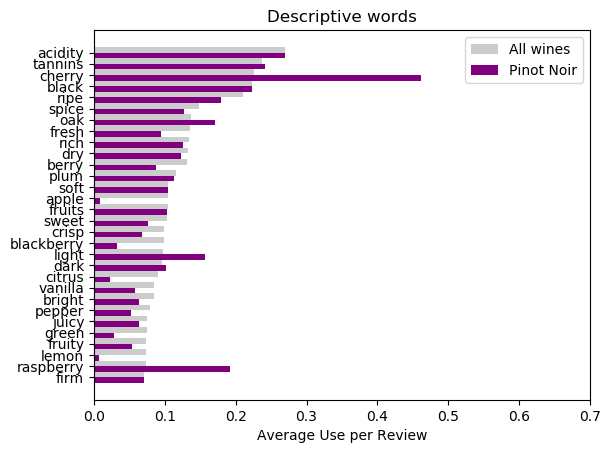

```python
plot_word_freq([i[0] for i in top_30_terms], means, pinot_means, 'Pinot Noir')
```

```python
pinot_means = get_means(df, None, top_30_terms)
```

```python
top_varieties = df_counted.variety.value_counts().index[0:15]
```

```python
top_varieties
```

```
Index(['Pinot Noir', 'Chardonnay', 'Cabernet Sauvignon', 'Red Blend',
       'Bordeaux-style Red Blend', 'Riesling', 'Sauvignon Blanc', 'Syrah',
       'Rosé', 'Merlot', 'Nebbiolo', 'Zinfandel', 'Sangiovese', 'Malbec',
       'Portuguese Red'],
      dtype='object')
```

### Plot the averarages for the to used words for each of the 15 wine varieties against the average use for all wines. Significant differences show how each variety is described differently.

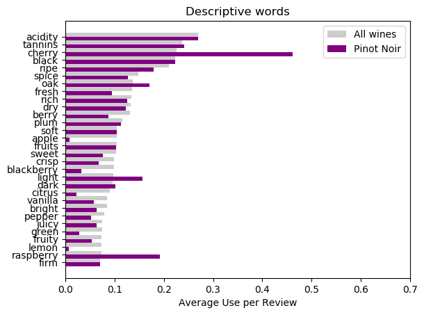

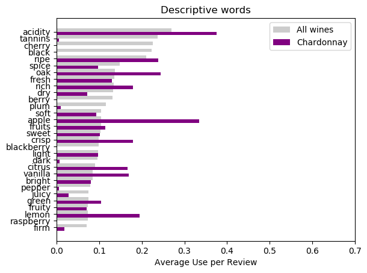

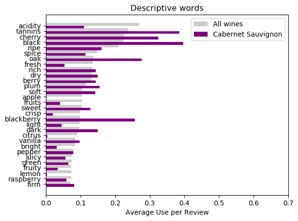

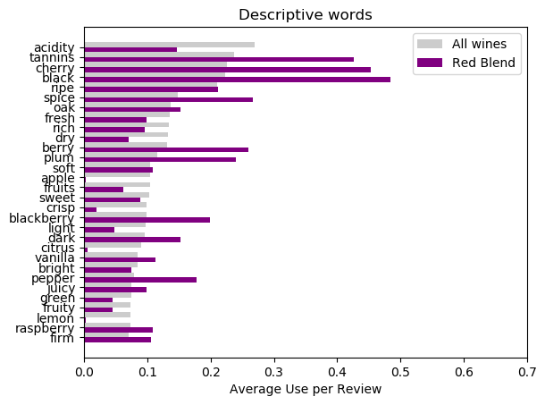

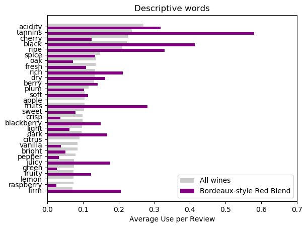

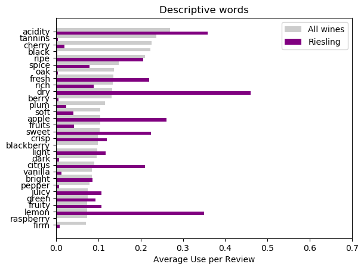

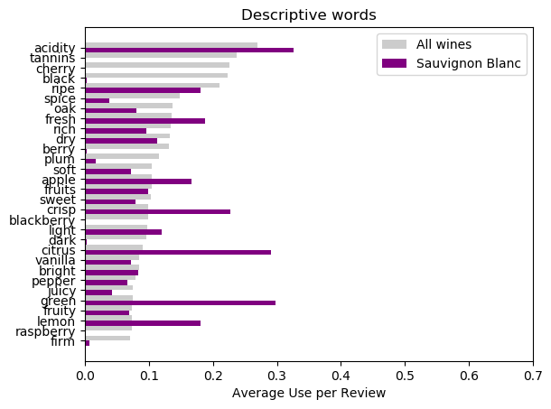

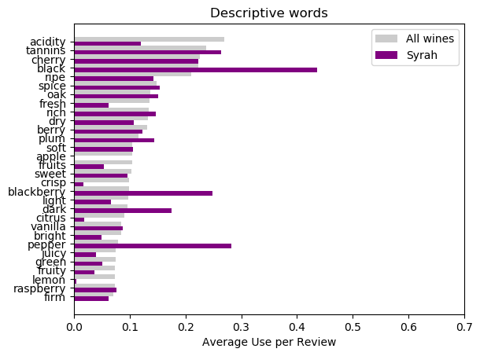

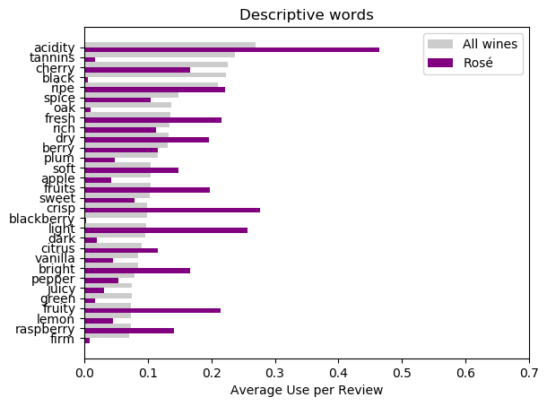

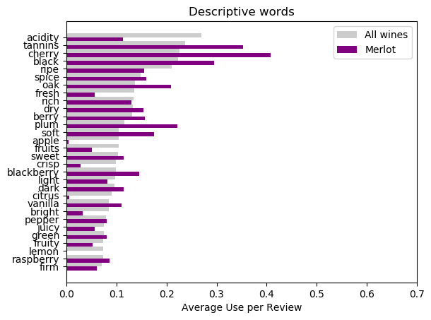

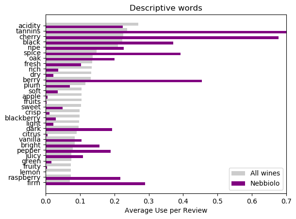

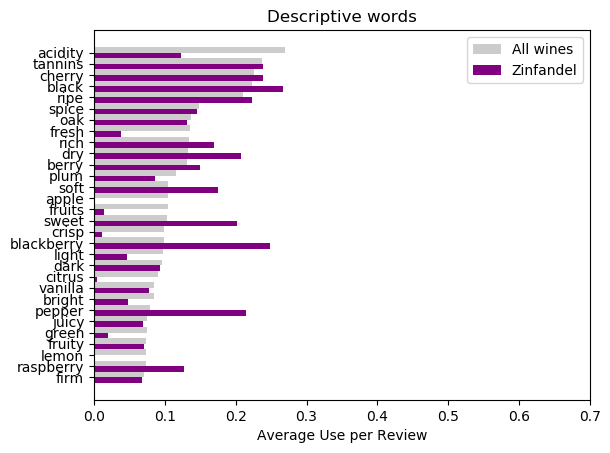

[3 more figures not shown]

```python
for variety in top_varieties:
    var_means = get_means(df, variety, top_30_terms)
    plot_word_freq([i[0] for i in top_30_terms], means, var_means, variety)
```

```python
df[df.variety=='Pinot Noir']['scores'][251]
```

```
[('inexpensive', 0.451939926982001),
 ('hill', 0.40201104658389863),
 ('suggestion', 0.38698752712119233),
 ('tomato', 0.3160682797811906),
 ('leaf', 0.3129696689723038),
 ('earthy', 0.24256449388313572),
 ('tannic', 0.2304730229442319),
 ('herb', 0.22795981550894667),
 ('spicy', 0.22336511006400506),
 ('berry', 0.17808961682969582),
 ('cherry', 0.1456928807792954),
 ('tannins', 0.14061855668880296)]
```

```python
for words in df[df.variety=='Pinot Noir']['scores'][251]:
    print (words[0])
```

```
inexpensive
hill
suggestion
tomato
leaf
earthy
tannic
herb
spicy
berry
cherry
tannins
```

```python
tf_counter = Counter()
for words in df[df.variety=='Pinot Noir']['scores'][251]:
    tf_counter.update({words[0]:1})
tf_counter
```

```
Counter({'inexpensive': 1,
         'hill': 1,
         'suggestion': 1,
         'tomato': 1,
         'leaf': 1,
         'earthy': 1,
         'tannic': 1,
         'herb': 1,
         'spicy': 1,
         'berry': 1,
         'cherry': 1,
         'tannins': 1})
```

```python
def get_all_unique_words(df_subview):
    """ Get high tf-idf words. For each row in the dataframe, get the
    5 highest scoring words.
    Args:
        df_subview: the dataframe
    Returns:
        A list of the top 5 scoring words for each of the rows
    """
    word_list = []
    for row in df_subview['scores']:
        i = 0
        for words in row:
            i = i+1
            word_list.append(words[0])
            if i==5:
                break
    return word_list
```

```python
def get_unique_words(df_subview):
    """ Get high tf-idf words. For each row in the dataframe, get the
    count of occurances of the 5 highest scoring words.
    Args:
        df_subview: the dataframe
    Returns:
        The top 10 most counted words.
    """
    tf_counter = Counter()
    for row in df_subview['scores']:
        i = 0
        for words in row:
            i = i + 1
            tf_counter.update({words[0]:1})
            if i==5:
                break
    return tf_counter.most_common(10)
```

```python
df['scores'][0]
```

```
[('unripened', 0.5204285850007428),
 ('brimstone', 0.3916317815200787),
 ('dried', 0.35226228352721617),
 ('broom', 0.3430466240893487),
 ('expressive', 0.2896573269421475),
 ('sage', 0.24255812438727267),
 ('brisk', 0.23409149004126484),
 ('tropical', 0.20811950745452892),
 ('herb', 0.18279954548409372),
 ('citrus', 0.15751857530610297),
 ('apple', 0.15337225023452414),
 ('acidity', 0.1068164057370034)]
```

### Get the words most used to uniquely describe each wine variety. These lists come from the tf-idf scores

```python
for variety in top_varieties:
    print("Unique Words for "+variety)
    print(get_unique_words(df[df.variety==variety]))
    print("")
```

```
Unique Words for Pinot Noir
[('silky', 313), ('cola', 256), ('strawberry', 235), ('raspberry', 197), ('light', 189), ('raspberries', 185), ('aging', 180), ('cranberry', 179), ('structure', 166), ('fruits', 162)]

Unique Words for Chardonnay
[('buttered', 446), ('yellow', 340), ('pineapple', 332), ('tropical', 318), ('apple', 293), ('apricot', 274), ('rounded', 272), ('pear', 257), ('butter', 249), ('toast', 240)]

Unique Words for Cabernet Sauvignon
[('blackberries', 226), ('currants', 204), ('currant', 200), ('cedar', 184), ('blackberry', 178), ('herbal', 176), ('black', 171), ('cassis', 166), ('cocoa', 142), ('tannic', 128)]

Unique Words for Red Blend
[('black', 499), ('blue', 270), ('underbrush', 237), ('polished', 209), ('espresso', 204), ('violet', 204), ('baking', 162), ('canaiolo', 151), ('easygoing', 149), ('raisin', 149)]

Unique Words for Bordeaux-style Red Blend
[('wood', 563), ('currant', 496), ('aging', 471), ('structure', 380), ('firm', 360), ('dense', 359), ('solid', 358), ('structured', 344), ('juicy', 339), ('fruity', 315)]

Unique Words for Riesling
[('lime', 129), ('lemon', 129), ('kabinett', 116), ('steely', 112), ('tangerine', 109), ('sugar', 100), ('pollen', 96), ('spry', 93), ('petrol', 92), ('perfumed', 90)]

Unique Words for Sauvignon Blanc
[('gooseberry', 215), ('green', 190), ('grapefruit', 189), ('tropical', 166), ('lime', 164), ('herbaceous', 147), ('tangy', 134), ('grass', 130), ('grassy', 129), ('herbal', 120)]

Unique Words for Syrah
[('smoked', 82), ('bacon', 77), ('syrahs', 73), ('black', 71), ('blackberries', 64), ('blue', 60), ('blueberry', 56), ('meat', 55), ('blackberry', 53), ('pepper', 50)]

Unique Words for Rosé
[('strawberry', 318), ('aftertaste', 276), ('fruity', 268), ('light', 224), ('caramel', 221), ('lively', 180), ('refreshing', 175), ('crisp', 163), ('bright', 151), ('watermelon', 137)]

Unique Words for Merlot
[('herbal', 72), ('cocoa', 72), ('nice', 65), ('simple', 65), ('cherries', 63), ('jammy', 61), ('currants', 56), ('cherry', 56), ('herb', 55), ('mocha', 51)]

Unique Words for Nebbiolo
[('balsamic', 235), ('menthol', 218), ('nebbiolo', 191), ('assertive', 186), ('barolo', 177), ('underbrush', 170), ('espresso', 139), ('sage', 131), ('violet', 130), ('truffle', 130)]

Unique Words for Zinfandel
[('briary', 100), ('barbecue', 81), ('alcohol', 66), ('jam', 63), ('port', 63), ('hot', 57), ('zins', 56), ('raspberries', 51), ('raisins', 51), ('jammy', 49)]

Unique Words for Sangiovese
[('underbrush', 212), ('black', 154), ('blue', 152), ('soil', 125), ('chianti', 117), ('menthol', 115), ('violet', 109), ('espresso', 107), ('assertive', 101), ('polished', 95)]

Unique Words for Malbec
[('berry', 99), ('herbal', 86), ('plum', 67), ('blackberry', 59), ('rubbery', 54), ('grapy', 49), ('malbecs', 46), ('black', 45), ('cahors', 44), ('saturated', 44)]

Unique Words for Portuguese Red
[('aging', 241), ('fruits', 205), ('fruity', 201), ('douro', 188), ('wood', 181), ('touriga', 173), ('nacional', 171), ('juicy', 146), ('dense', 141), ('soft', 139)]
```

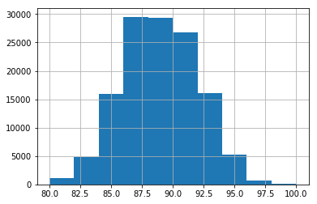

```python
df.points.hist(bins=10)
```

```python
print("Unique Words for high points")
print(get_unique_words(df[df.points>=97]))
```

```
Unique Words for high points
[('stunning', 10), ('opulent', 10), ('impressive', 10), ('structure', 10), ('decades', 10), ('powerful', 10), ('impeccable', 9), ('magnificent', 9), ('superb', 8), ('botrytis', 7)]
```

```python
print("Unique Words for low points")
print(get_unique_words(df[df.points<=82]))
```

```
Unique Words for low points
[('simple', 199), ('sweet', 131), ('vegetal', 107), ('sugary', 94), ('green', 90), ('harsh', 90), ('sour', 87), ('dull', 80), ('soft', 75), ('bitter', 75)]
```

```python
print("Unique Words for middle of the road points")
print(get_unique_words(df[(df.points>=85) & (df.points<=92)]))
```

```
Unique Words for middle of the road points
[('fruity', 1692), ('black', 1618), ('aftertaste', 1539), ('aging', 1456), ('wood', 1408), ('rounded', 1297), ('perfumed', 1220), ('currant', 1140), ('fruits', 1085), ('light', 1084)]
```

```python
df.price.describe()
```

```
count    129907.000000
mean         35.884509
std          41.611211
min           4.000000
25%          17.000000
50%          25.428571
75%          43.000000
max        3300.000000
Name: price, dtype: float64
```

```python
(df.price>200).sum()
```

```
789
```

```python
(df.price<9).sum()
```

```
1530
```

```python
((df.price>20) & (df.price <40)).sum()
```

```
42803
```

## Questions 2 and 3 are answered here. I'm collecting the unique words used in each wine review (selected by top tf-idf scores) and slicing them by wine prices and wine ratings. The lists I assemple are used to make word clouds.

```python
print("Unique Words for expensive wines (>$200)")
print(get_unique_words(df[(df.price>200)]))
```

```
Unique Words for expensive wines (>$200)
[('powerful', 48), ('impressive', 31), ('aging', 29), ('opulent', 28), ('dense', 25), ('structure', 19), ('black', 18), ('solid', 15), ('beautifully', 15), ('wood', 14)]
```

```python
print("Unique Words for cheap wines (<$9)")
print(get_unique_words(df[(df.price<9)]))
```

```
Unique Words for cheap wines (<$9)
[('fruity', 86), ('light', 76), ('simple', 61), ('soft', 53), ('easy', 45), ('bright', 37), ('fruits', 36), ('clean', 35), ('vinho', 34), ('sweet', 34)]
```

```python
print("Unique Words for average priced wines (Between $20 and $40)")
print(get_unique_words(df[(df.price>20) & (df.price <40)]))
```

```
Unique Words for average priced wines (Between $20 and $40)
[('black', 618), ('aging', 611), ('wood', 587), ('aftertaste', 509), ('rounded', 463), ('fruity', 460), ('perfumed', 412), ('light', 389), ('currant', 381), ('yellow', 371)]
```

```python
the_words = get_all_unique_words(df[(df.price>200)])
wordcloud = WordCloud(background_color="white").generate(" ".join(the_words))
```

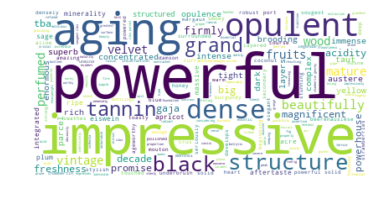

```python
plt.imshow(wordcloud, interpolation='bilinear')
plt.axis("off")
plt.show()
```

```python
def generate_wordcloud(word_list):
    """ Generate wordcloud from list of words
    Args:
        word_list: the list
    Returns:
        plots the cloud
    """
    wordcloud = WordCloud(background_color="white").generate(" ".join(word_list))
    plt.imshow(wordcloud, interpolation='bilinear')
    plt.axis("off")
    plt.show()
```

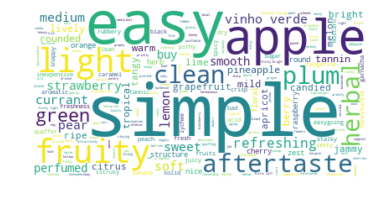

```python
generate_wordcloud(get_all_unique_words(df[(df.price<10)]))
```

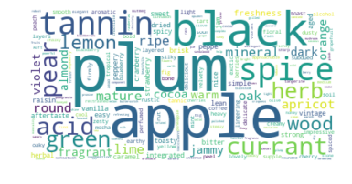

```python
generate_wordcloud(get_all_unique_words(df[(df.price>20) & (df.price <40)]))
```

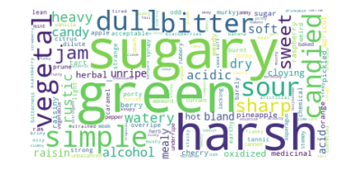

```python
generate_wordcloud(get_all_unique_words(df[df.points<=82]))
```

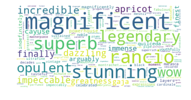

```python
generate_wordcloud(get_all_unique_words(df[df.points>97]))
```

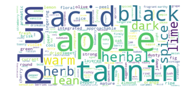

```python
generate_wordcloud(get_all_unique_words(df[(df.points>=85) & (df.points<=92)]))
```